# CA1_2201858_DELE_PARTB

## DELE CA1 PART B : RECURRENT NEURAL NETWORK

Name : Dario Prawara Teh Wei Rong | Class : DAAA / FT / 2B / 04 | Admission Number : 2201858

Objective : Build a next-word predictor, given a sequence of words using a RNN model or collection of models.

Background Information : The input to the model can be a sequence of words of any length while the output of the model is a word that follows that sequence of input words. The model should also be capable of producing different sequences of output texts, given the same input.

### BACKGROUND RESEARCH

- **What is an RNN?** : An RNN processes sequences by maintaining a hidden state that captures the information of previous elements. Unlike feedforward neural networks, RNNs have a looped architecture allowing information to persist.
- **Why Use RNNs for Text Generation?** : Text generation involves predicting the next word or character in a sequence, making RNNs a natural choice due to their sequential nature and memory of past information.
- **Challenges with RNNs** : Despite having clear advantages, RNNs have limitations, such as difficulty learning long-range dependencies within a sequence. This is due to the vanishing gradient problem, where gradients become too small for effective learning through long sequences.
- **Advances in RNNs for Text Generation** : To address these issues, advanced versions of RNNs, like Long Short-Term Memory (LSTM) units and Gated Recurrent Units (GRUs) were developed. These architectures introduce gates that regulate the flow of information and allow the network to learn dependencies over longer sequences.

### INITIALIZING MODULES AND LIBRARIES

- Import necessary libraries for pre-processing, data exploration, feature engineering and model evaluation.
- Some libraries used include tensorflow, numpy, pandas, matplotlib, seaborn, sklearn and keras.

```python
# Import the necessary modules and libraries

# TensorFlow for deep learning framework
import tensorflow as tf
from tensorflow.keras.models import Sequential, Model
from tensorflow.keras.layers import LSTM, Dense, Embedding, LayerNormalization, SimpleRNN, Dropout, Input, GRU, Bidirectional
from tensorflow.keras.preprocessing.text import Tokenizer
from tensorflow.keras.preprocessing.sequence import pad_sequences

# Visualization and Processing Libraries
import numpy as np
import pandas as pd
import matplotlib.pyplot as plt
import seaborn as sns
from collections import Counter
from nltk.util import ngrams
from nltk.corpus import wordnet, stopwords
import nltk
from nltk.tokenize import word_tokenize
from itertools import combinations
from sklearn.model_selection import train_test_split
from sklearn.feature_extraction.text import CountVectorizer
import random
import re
import textstat

# Keras metrics for model evaluation
from tensorflow.keras.metrics import Precision, Recall, CategoricalAccuracy
from tensorflow.keras.regularizers import l1, l2, l1_l2
from tensorflow.keras.callbacks import EarlyStopping, ReduceLROnPlateau, LearningRateScheduler
from tensorflow.keras.optimizers.schedules import CosineDecay
from tensorflow.keras import utils
import keras.backend as K
from tensorflow.keras.optimizers import Adam, SGD, RMSprop
import keras_tuner as kt

# Ignore warnings
import warnings
warnings.filterwarnings('ignore')
```

### PERFORM CHECK FOR GPU

- Ensure GPU can be found when using tf.config and list_physical_devices.
- Avoid OOM errors by setting GPU memory consumption growth.

```python
# Avoid OOM errors by setting GPU Memory Consumption Growth
gpus = tf.config.experimental.list_physical_devices('GPU')
for gpu in gpus:
    tf.config.experimental.set_memory_growth(gpu, True)

# Show the GPU
gpu
```

```
PhysicalDevice(name='/physical_device:GPU:0', device_type='GPU')
```

### SETTING RANDOM SEED FOR REPRODUCTIBILITY

- To ensure reproductibility of results, we will be setting random seed to ensure results are reproducible.

```python
tf.random.set_seed(88)
```

### DEFINING UTILITY FUNCTIONS FOR ANALYSIS

- Before analyzing and importing the dataset, below are some utility functions that will be used in the analysis of text and to visualize model performance below.

```python
# Define Utility Functions for Analysis later

# Plot loss and accuracy curve
def plot_curve(history):
    if not isinstance(history, pd.DataFrame):
        history = pd.DataFrame(history)
    epochs = range(1, len(history) + 1)

    # Create two subplots: one for loss and one for accuracy
    fig, (ax1, ax2) = plt.subplots(1, 2, figsize=(20, 10))

    # Plot training and validation loss
    ax1.plot(epochs, history['loss'], label='Training Loss')
    ax1.plot(epochs, history['val_loss'], label='Validation Loss')
    ax1.set_title('Training and Validation Loss')
    ax1.set_xlabel('Epochs')
    ax1.set_ylabel('Loss')
    ax1.legend()

    # Plot training and validation accuracy
    ax2.plot(epochs, history['accuracy'], label='Training Accuracy')
    ax2.plot(epochs, history['val_accuracy'], label='Validation Accuracy')
    ax2.set_title('Training and Validation Accuracy')
    ax2.set_xlabel('Epochs')
    ax2.set_ylabel('Accuracy')
    ax2.legend()

    plt.show()

# Get top_k_sampling
def top_k_sampling(preds, k=10):
    # Sort the predictions and select the top k
    sorted_indices = np.argsort(preds)[-k:]
    top_k_preds = preds[sorted_indices]

    # Normalize the top k predictions to sum to 1
    top_k_preds = top_k_preds / np.sum(top_k_preds)

    # Randomly select from the top k predictions
    chosen_index = np.random.choice(sorted_indices, p=top_k_preds)
    return chosen_index

# Function to predict next N words
def predict_next_n_words(model, tokenizer, sequences, seed_texts, n, k=10):
    predicted_sequences = []
    model_input_length = 34
    loss, acc = model.evaluate(X_val, y_val)

    for index, sequence in enumerate(sequences):
        original_sequence_length = len(sequence)  # Store the original sequence length
        generated_words = []

        for _ in range(n):
            # Predict the next word probabilities
            predicted_probs = model.predict(np.array([sequence]), verbose=0)[0]

            # Use top-k sampling to choose the next word index
            predicted_index = top_k_sampling(predicted_probs, k)

            # Append the predicted word to the sequence
            sequence = np.append(sequence, predicted_index)

            # Trim the sequence if it exceeds the model's input length
            if len(sequence) > model_input_length:
                sequence = sequence[-model_input_length:]

            # Append the predicted word to the list of generated words
            generated_words.append(tokenizer.index_word.get(predicted_index, '?'))

        # Join the generated words to form the predicted text
        predicted_text = ' '.join(generated_words)
        predicted_sequences.append(predicted_text)

        # Print the original, predicted texts and Flesch Reading Ease Score
        print("*"*75)
        print("Original Text: " + seed_texts[index])
        print("Predicted Text: " + seed_texts[index] + " " + predicted_sequences[index])
        # calculate perplexity
        perplexity = np.exp(loss)
        print(f'Validation Perplexity: {perplexity}\n')

# Compile Results Function
def compile_results(model_history, model_name, batch_size, results=None):
    best_val_idx = np.argmin(model_history['val_loss'])
    result = {
        'Model Name': model_name,
        'Epochs': len(model_history['loss']),
        'Batch Size': batch_size,
        'Train Loss': model_history['loss'][best_val_idx],
        'Val Loss': model_history['val_loss'][best_val_idx],
        'Train Acc': model_history['accuracy'][best_val_idx],
        'Val Acc': model_history['val_accuracy'][best_val_idx],
        '[Train - Val] Acc': model_history['accuracy'][best_val_idx] - model_history['val_accuracy'][best_val_idx],
    }

    result_df = pd.DataFrame([result])

    if results is not None:
        return pd.concat([results, result_df], ignore_index=True)
    else:
        return result_df

# Create an initial DataFrame and set it to None
result_df = None
```

### IMPORT AND OVERVIEW OF 'TRAIN' DATASET

- Import the csv data using pandas function `pd.read_csv` to obtain the CSV-formatted dataset for the RNN model.
- To get an overview of the dataset provided, we will first use pandas function `.head()` to retrieve the first 5 rows of data.

**IMPORT AND OVERVIEW OF DATA**

- From the importation of the data, we see that there are 1000 quotes available in the dataset provided.

```python
# Import and read CSV data
df = pd.read_csv('train.csv')

# Overview of Dataset
print("Overview of Dataset for RNN :")
print(f"Shape of the Dataset: {df.shape}")
df.head()
```

```
Overview of Dataset for RNN :
Shape of the Dataset: (1000, 1)
```

|  | Quotes |
| --- | --- |
| 0 | Embrace the beauty of every sunrise; it's a fr... |
| 1 | Embrace challenges; they are the stepping ston... |
| 2 | Embrace the rhythm of life and let it dance th... |
| 3 | Embrace kindness, for it has the power to chan... |
| 4 | Embrace the journey, for it leads to the desti... |

### IMPORTING SEED TEXTS FOR TEST DATA

- Based on the `seed_texts` provided, we will be using this for test data to test and evaluate our model's performance by predicting the next 10 words.

```python
seed_texts = [
    'embrace each day',
    'radiate some',
    'believe that',
    "life's actual purpose is",
    'dance through each and every',
    'let your time and energy',
    'every person is',
    'our country Singapore is',
    'planet earth is',
    'morning and evening would make it'
]
```

### STATISTICAL ANALYSIS OF INPUT DATA

Before pre-processing any data, we will take a look at some statistical analysis with the input data provided. Note that the analysis may change later on upon performing pre-processing on the data.

- Count of Most Common and Least Common Words
- Distribution of Quote Lengths
- N-gram Analysis
- Co-occurrence and Correlation Analysis
- Analysis for Duplicate Quotes

Before performing the statistical analysis, we will first convert all the words in the dataframe to lowercase for consistent analysis.

```python
# Convert the quotes to lowercase for consistent analysis
df['Quotes'] = df['Quotes'].str.lower()
```

**GRAPH 1 : BAR CHART OF TOP 20 MOST COMMON WORDS**

- From the analysis, it shows that the word **the** is the most common word that can be found in the dataset.
- Thw rods range from common English articles and propositions like "the" and "of" to more thematic words such as "dance," "life's," "embrace," and "through," hinting at a text with themes centered around life and its experiences.

```
Top 20 Most Common Words:
==========================
Word: 'the', Frequency: 986
Word: 'of', Frequency: 751
Word: 'your', Frequency: 430
Word: 'and', Frequency: 366
Word: 'a', Frequency: 325
Word: 'in', Frequency: 280
Word: 'is', Frequency: 271
Word: 'for', Frequency: 234
Word: 'let', Frequency: 230
Word: 'be', Frequency: 211
Word: 'it', Frequency: 196
Word: 'to', Frequency: 190
Word: 'every', Frequency: 168
Word: 'our', Frequency: 149
Word: 'that', Frequency: 144
Word: 'you', Frequency: 142
Word: 'dance', Frequency: 124
Word: 'life's', Frequency: 123
Word: 'embrace', Frequency: 116
Word: 'through', Frequency: 115
```

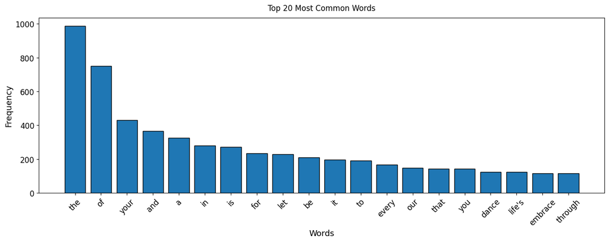

```python
# Find count of most common words in the dataset

# Tokenize the text into individual words
all_words = df['Quotes'].str.split(expand=True).stack()

# Count the frequency of each word and get most common words
word_counts = Counter(all_words)
most_common_words = word_counts.most_common(20)

# Print the top 20 most common words
print("Top 20 Most Common Words:\n==========================")
for word, count in most_common_words:
    print(f"Word: '{word}', Frequency: {count}")

# Bar plot of most common words
plt.figure(figsize=(16, 5))
plt.bar(*zip(*most_common_words), edgecolor='black')
plt.title('Top 20 Most Common Words', y=1.02)
plt.xticks(rotation=45, fontsize=12)
plt.yticks(fontsize=12)
plt.xlabel('Words', fontsize=13)
plt.ylabel('Frequency', fontsize=13)

plt.show()
```

**GRAPH 2 : BAR CHART OF TOP 20 LEAST COMMON WORDS**

- From this analysis, it shows that in the dataset, the bottom 20 least common words include those such as 'beginnings', 'reside', 'goodness' and more.

```
Top 20 Least Common Words:
==========================
Word: 'beginnings,', Frequency: 1
Word: 'reside', Frequency: 1
Word: 'goodness,', Frequency: 1
Word: 'lightheartedness.', Frequency: 1
Word: 'fortitude', Frequency: 1
Word: 'warmth.', Frequency: 1
Word: 'smiles', Frequency: 1
Word: 'trail', Frequency: 1
Word: 'appreciation.', Frequency: 1
Word: 'filling', Frequency: 1
Word: 'focus', Frequency: 1
Word: 'contentment.', Frequency: 1
Word: 'encounter.', Frequency: 1
Word: 'pursue', Frequency: 1
Word: 'touch.', Frequency: 1
Word: 'souls', Frequency: 1
Word: 'dwells', Frequency: 1
Word: 'presents', Frequency: 1
Word: 'brighter.', Frequency: 1
Word: 'chase', Frequency: 1
```

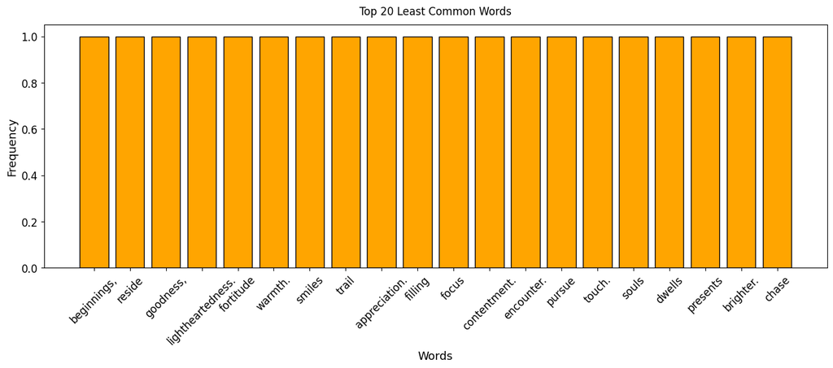

```python
# Find count of least common words in the dataset

# Tokenize the text into individual words
all_words = df['Quotes'].str.split(expand=True).stack()

# Count the frequency of each word and get least common words
word_counts = Counter(all_words)
least_common_words = word_counts.most_common()[:-21:-1]

# Print the top 20 least common words
print("Top 20 Least Common Words:\n==========================")
for word, count in least_common_words:
    print(f"Word: '{word}', Frequency: {count}")

# Bar plot of least common words
plt.figure(figsize=(16, 5))
plt.bar(*zip(*least_common_words), edgecolor='black', color='orange')
plt.title('Top 20 Least Common Words', y=1.02)
plt.xticks(rotation=45, fontsize=12)
plt.yticks(fontsize=12)
plt.xlabel('Words', fontsize=13)
plt.ylabel('Frequency', fontsize=13)

plt.show()
```

**GRAPH 3 : HISTOGRAM FOR DISTRIBUTION OF QUOTE LENGTHS**

- From the graph, it shows that the distribution peaks around the 10-15 length interval, suggesting that most quotes in the analyzed dataset are within this range.
- The frequency decreases as the length of quotes increases, indicating that longer quotes are less common while shorter quotes are more common in the dataset.

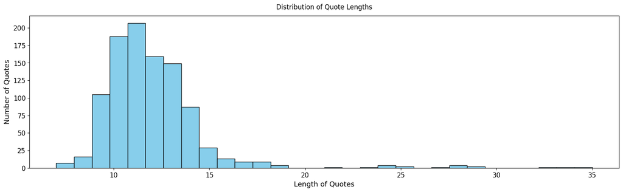

```python
# Distribution of quote lengths

# Get the sequence length of each quote
sequence_lengths = df['Quotes'].str.split().apply(len)

# Histogram of sequence lengths
plt.figure(figsize=(16, 5))
plt.hist(sequence_lengths, bins=30, color='skyblue', edgecolor='black')
plt.title('Distribution of Quote Lengths', y=1.02)
plt.xticks(fontsize=12)
plt.yticks(fontsize=12)
plt.xlabel('Length of Quotes', fontsize=13)
plt.ylabel('Number of Quotes', fontsize=13)

# Show graph
plt.tight_layout()
plt.show()
```

**GRAPH 4 : N-GRAM ANALYSIS OF QUOTES**

- For the bigrams, the most frequent pair is ('let', 'your'), appearing 161 times, followed by ('be', 'the') with 154 occurrences. Other notable bigrams include ('dance', 'through') and ('embrace', 'the'), which suggest motivational or inspirational themes in the text.
- For the trigrams, ('believe', 'in', 'yourself,') leads with 100 occurrences, emphasizing a self-empowerment theme. The trigram ('dance', 'through', 'the') appears 84 times, further reinforcing the recurring theme of movement or progress.

```python
# Performing N-gram Analysis

# Bigram Analysis
bigrams = ngrams(all_words, 2)
bigram_counts = Counter(bigrams)
most_common_bigrams = bigram_counts.most_common(10)

# Trigram Analysis
trigrams = ngrams(all_words, 3)
trigram_counts = Counter(trigrams)
most_common_trigrams = trigram_counts.most_common(10)

# Printing the results
print("Top 10 Most Common Bigrams:")
for bigram, count in most_common_bigrams:
    print(f"Bigram: {bigram}, Frequency: {count}")

print("\nTop 10 Most Common Trigrams:")
for trigram, count in most_common_trigrams:
    print(f"Trigram: {trigram}, Frequency: {count}")
```

```
Top 10 Most Common Bigrams:
Bigram: ('let', 'your'), Frequency: 161
Bigram: ('be', 'the'), Frequency: 154
Bigram: ('is', 'a'), Frequency: 133
Bigram: ('of', 'your'), Frequency: 115
Bigram: ('in', 'the'), Frequency: 109
Bigram: ('for', 'it'), Frequency: 104
Bigram: ('dance', 'through'), Frequency: 101
Bigram: ('believe', 'in'), Frequency: 101
Bigram: ('in', 'yourself,'), Frequency: 100
Bigram: ('embrace', 'the'), Frequency: 90

Top 10 Most Common Trigrams:
Trigram: ('believe', 'in', 'yourself,'), Frequency: 100
Trigram: ('dance', 'through', 'the'), Frequency: 84
Trigram: ('in', 'yourself,', 'and'), Frequency: 78
Trigram: ('for', 'it', 'is'), Frequency: 74
Trigram: ('it', 'is', 'the'), Frequency: 68
Trigram: ('and', 'you', 'will'), Frequency: 68
Trigram: ('yourself,', 'and', 'you'), Frequency: 67
Trigram: ('this', 'morning,', 'let'), Frequency: 52
Trigram: ('and', 'let', 'it'), Frequency: 50
Trigram: ('let', 'it', 'be'), Frequency: 42
```

**GRAPH 5 : PERFORMING CO-OCCURENCE ANALYSIS**

- The pair ('the', 'of') is the most common, occurring 1039 times, which suggests the frequent use of this phrase structure in the analyzed text, possibly in formal or academic writing where such constructions are common. The pair ('let', 'your') appears 497 times, which, along with other pairs like ('be', 'the'), ('is', 'a'), and ('of', 'your'), indicates a pattern of encouraging or instructive language.
- Additionally, pairs like ('believe', 'in'), ('dance', 'through'), and ('in', 'yourself,') occur with significant frequency, pointing towards themes of empowerment, action, and self-confidence.

```python
# Performing co-occurence and correlation analysis

def co_occurrence(words, window_size):
    # Initialize a counter to store co-occurrences
    co_occurrences = Counter()

    # Iterate through the words to create windows of the specified size
    for i in range(len(words) - window_size + 1):
        # Create a window of words
        window = words[i : i + window_size]

        # Count co-occurrences for each combination of words in the window
        for word1, word2 in combinations(window, 2):
            co_occurrences[(word1, word2)] += 1

    return co_occurrences

# Calculate co-occurrences for a window size of 4
co_occurrences = co_occurrence(all_words, 4)

# Print the 10 most common co-occurring word pairs
print("Top 10 Co-occurring Word Pairs:")
for pair, count in co_occurrences.most_common(10):
    print(f"Pair: {pair}, Frequency: {count}")
```

```
Top 10 Co-occurring Word Pairs:
Pair: ('the', 'of'), Frequency: 1039
Pair: ('let', 'your'), Frequency: 497
Pair: ('be', 'the'), Frequency: 469
Pair: ('is', 'a'), Frequency: 417
Pair: ('of', 'your'), Frequency: 363
Pair: ('in', 'the'), Frequency: 333
Pair: ('for', 'it'), Frequency: 312
Pair: ('believe', 'in'), Frequency: 305
Pair: ('dance', 'through'), Frequency: 303
Pair: ('in', 'yourself,'), Frequency: 300
```

**GRAPH 6 : BAR CHART OF DUPLICATE QUOTES**

- From the bar chart, we can see that there are duplicate rows of quotes present in the dataset.
- Hence, we will be removing these duplicate quotes later on during pre-processing as they would introduce biasness to the model, causing it to predict these words more often than others.

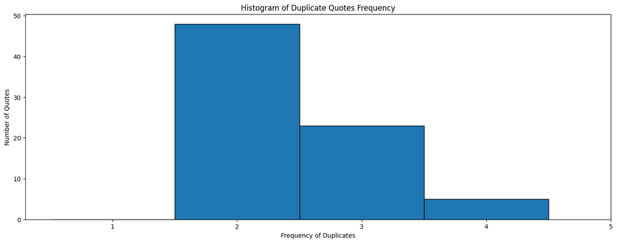

```python
# Count the occurrences of each quote
quote_counts = df['Quotes'].value_counts()

# Filter for quotes that appear more than once (duplicates)
duplicate_quote_counts = quote_counts[quote_counts > 1]

# Plotting the histogram of duplicate counts
plt.figure(figsize=(17, 6))
plt.hist(duplicate_quote_counts, bins=range(1, duplicate_quote_counts.max()+1), align='left', edgecolor='black')
plt.title('Histogram of Duplicate Quotes Frequency')
plt.xlabel('Frequency of Duplicates')
plt.ylabel('Number of Quotes')
plt.xticks(range(1, duplicate_quote_counts.max()+1))  # Set x-ticks to be integers (for frequency count)
plt.show()
```

### DATA PRE-PROCESSING AND FEATURE ENGINEERING

For data pre-processing, we will be covering the following steps to pre-process and prepare the data provided for model building :

- Remove Duplicate Quotes
- Check and Filter for Special Characters / Numbers
- Tokenization to Map Words
- Create Input-Output Pairs and Sequencing
- Train-Validation Split

#### REMOVING DUPLICATE QUOTES

- To ensure that the model is trained with unique quote data, we will remove duplicates to prevent the model from generalizing to a certain quote phrasing.
- Based on the result, we see that the number of duplicate quotes have been successfully removed.

```python
# Check for duplicate entries in the 'Quotes' column
duplicates = df[df.duplicated('Quotes')]

# Remove duplicate entries, keeping the first occurrence
df = df.drop_duplicates('Quotes', keep='first')
removed_duplicates = df[df.duplicated('Quotes')]

# Print before and after removing the duplicates
print(f"Count of Duplicate Quotes Before Removal: {len(duplicates)}")
print(f"Count of Duplicate Quotes After Removal: {len(removed_duplicates)}")
```

```
Count of Duplicate Quotes Before Removal: 110
Count of Duplicate Quotes After Removal: 0
```

**CONVERT DATAFRAME TO A LIST**

- Convert the dataframe to a list to make it compatible for RNN training and for easier accessibility.
- Here, we see that the number of quotes is now 890, indicating that the removal of duplicate quotes was successful.

```python
# Conversion of dataframe to a list
data = list(df.Quotes.values)

print(f"There are {len(data)} quotes found in this dataset.\n")
print("Example of First 5 Quotes in the Dataset :\n")

# Printing the first 5 quotes in the list
print(data[:5])
```

```
There are 890 quotes found in this dataset.

Example of First 5 Quotes in the Dataset :

["embrace the beauty of every sunrise; it's a fresh chance to paint your world with joy.", 'embrace challenges; they are the stepping stones to your greatest victories.', 'embrace the rhythm of life and let it dance through your soul.', 'embrace kindness, for it has the power to change the world one…
```

#### CHECK FOR SPECIAL CHARACTERS OR NUMBERS

- Check the text for any special characters or numbers and remove these characters to ensure processed texts.
- Some checks done included removal of periods, commas, semicolons, while keeping key characters like letters and quotation marks.

```python
# Check for Special Characters / Numbers
def clean_text(text):
    # Remove special characters, numbers, commas, periods, and semicolons
    text = re.sub(r'[^a-zA-Z\s\'-]', '', text)
    return text

data = [clean_text(quote) for quote in data]

# Show the first 5 quotes of data
print("Cleaned Data : Removed Special Characters and Numbers")
data[:5]
```

```
Cleaned Data : Removed Special Characters and Numbers
```

```
["embrace the beauty of every sunrise it's a fresh chance to paint your world with joy",
 'embrace challenges they are the stepping stones to your greatest victories',
 'embrace the rhythm of life and let it dance through your soul',
 'embrace kindness for it has the power to change the world one heart at a time',
 'embrace the journey for it leads to the destination of your dreams']
```

**TOKENIZATION TO MAP WORDS WITH INDEXING**

- Using tokenization, we are able to break down the quote sequences into individual words.
- The tokenized labels will start from 1 as 0 is reserved for padding.
- Check the total number of words found in the data after tokenizing to ensure data remains consistent.

```python
# Instantiate a single tokenizer object
tokenizer = Tokenizer()

# Fit the tokenizer on the data provided
tokenizer.fit_on_texts(data)

# Display the index size
print(f"Original Data Word Index Size: {len(tokenizer.word_index)+1}")
print(list(tokenizer.word_index.items())[:10])
```

```
Original Data Word Index Size: 1199
[('the', 1), ('of', 2), ('your', 3), ('and', 4), ('a', 5), ('is', 6), ('in', 7), ('for', 8), ('let', 9), ('to', 10)]
```

**TOKENIZING TEXTS TO INTEGER SEQUENCES**

- Tokenize texts in a sequence to its integer value from fitting on text earlier using `.texts_to_sequences`.
- This allows us to visualize how the tokenized data will look like.

```python
# Convert texts to sequences
input_sequence = []

# Tokenize each datapoint in the original data
for datapoint in data:
    token_list = tokenizer.texts_to_sequences([datapoint])[0]
    input_sequence.append(token_list)

# Display examples from original data
print(f'Total Number of Quotes : {len(input_sequence)}\n')
print("Original Text and Tokenized Sequences:\n")
for i in range(3):
    print(f"Example {i+1}:")
    print(f"Original Text: {data[i]}")
    print(f"Tokenized Sequence: {input_sequence[i]}\n")
```

```
Total Number of Quotes : 890

Original Text and Tokenized Sequences:

Example 1:
Original Text: embrace the beauty of every sunrise it's a fresh chance to paint your world with joy
Tokenized Sequence: [17, 1, 49, 2, 13, 77, 372, 5, 163, 486, 10, 101, 3, 46, 22, 52]

Example 2:
Original Text: embrace challenges they are the stepping stones to your greatest victories
Tokenized Sequence: [17, 148, 33, 20, 1, 373, 487, 10, 3, 374, 687]

Example 3:
Original Text: embrace the rhythm of life and let it dance through your soul
Tokenized Sequence: [17, 1, 119, 2, 31, 4, 9, 11, 24, 28, 3, 40]
```

**PERFORMING FURTHER EXPLORATORY DATA ANALYSIS**

Next, before creating input-output pairs, we will be looking at the number of words per sentence, and perform another N-gram analysis but this time it will be done on the list sequences instead of the original data.

**HISTOGRAM FOR NUMBER OF WORDS PER SENTENCE**

- From the histogram, it shows that the length of quote sequences range from 7 to 35, and the peak shows that most sequences range between 10 to 15 words.
- Based on the curve, we see that the distribution of the length of quote sequences seem positively skewed.

```
Minimum Length: 7
Maximum Length: 35
Mean Length: 11.931460674157304
```

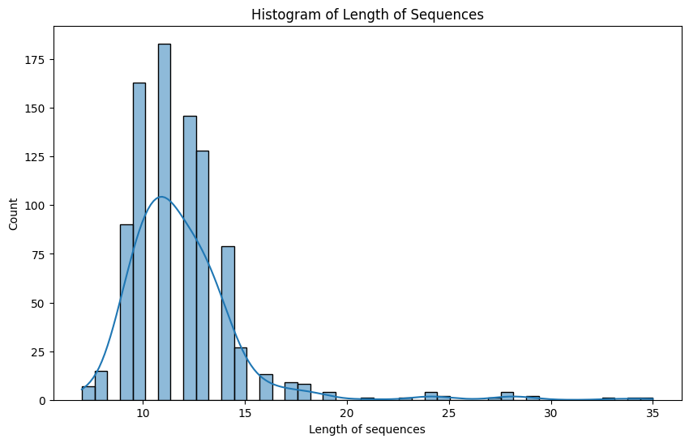

```python
length = [len(sequence) for sequence in input_sequence]
print(f"Minimum Length: {min(length)}\nMaximum Length: {max(length)}\nMean Length: {np.mean(length)}")

# Plot histogram
fig, ax = plt.subplots(figsize=(10,6))
sns.histplot(length,ax=ax, kde=True)
ax.set_xlabel(xlabel='Length of sequences')
ax.set_title(label='Histogram of Length of Sequences')
plt.show()
```

**N-GRAM ANALYSIS ON LIST SEQUENCES**

- From the results, we see the bigram that is most frequent is 'morning let' and for trigrams it is 'morning let actions', indicating that our model is likely to predict 'let' if given 'morning' as this is the most frequent bigram, and 'actions' if given 'morning let'.

```python
# Function to get n-grams
def get_top_ngrams(list_sequences, n=None, top_k=10):
    vec = CountVectorizer(ngram_range=(n, n), stop_words='english').fit(list_sequences)
    bag_of_words = vec.transform(list_sequences)
    sum_words = bag_of_words.sum(axis=0)
    words_freq = [(word, sum_words[0, idx]) for word, idx in vec.vocabulary_.items()]
    words_freq = sorted(words_freq, key=lambda x: x[1], reverse=True)
    return words_freq[:top_k]

# Bigrams
top_bigrams = get_top_ngrams(data, 2, 10)
# Trigrams
top_trigrams = get_top_ngrams(data, 3, 10)

print(f"Top 10 Bigrams:\n{top_bigrams}\n\nTop 10 Trigrams:\n{top_trigrams}")
```

```
Top 10 Bigrams:
[('morning let', 51), ('embrace power', 25), ('let kindness', 17), ('let actions', 17), ('let heart', 15), ('lion city', 15), ('singapore skyline', 15), ('singapore nature', 15), ('life garden', 13), ('embrace symphony', 12)]

Top 10 Trigrams:
[('morning let actions', 13), ('heart lion city', 11), ('morning let kindness', 11), ('life garden flourishes', 8), ('tapestry woven threads', 6), ('singapore nature sanctuary', 6), ('morning let gratitude', 6), ('let heart lead', 5), ('heart lead way', 5), ('radiate joy let', 5)]
```

### CREATION OF INPUT-OUTPUT WORD PAIRS

- For each tokenized sequence, we will generate pairs where each input is a subsequence of the tokens, and the output is the next token in the sequence.
- For this analysis, we will create as many input-output pair sequences as possible to get as much data as we are able to.
- This method ensures a comprehensive set of input-output pairs, capturing various lengths of preceding token sequences for each token in the data.

```python
# Function to get input-output pairs
def generate_tokenized_pairs(input_sequence):
    # Find the length of the longest sequence to determine the maximum window size
    max_length = max(len(sequence) for sequence in input_sequence)
    tokenized_pairs = []

    # Generate pairs of various lengths for each sequence
    for sequence in input_sequence:
        for window_size in range(1, max_length):
            for i in range(len(sequence) - window_size):
                pair = sequence[i:i + window_size + 1]
                tokenized_pairs.append(pair)

    # Include each full sequence as a pair
    for sequence in input_sequence:
        tokenized_pairs.append(sequence)

    return tokenized_pairs

# Get input-output pair for training data
input_output_pair = generate_tokenized_pairs(input_sequence)
print(f'Total number of input-output pairs in Training Data: {len(input_output_pair)}')
```

```
Total number of input-output pairs in Training Data: 62959
```

**LENGTH OF EACH N-GRAM IN THE INPUT-OUTPUT PAIR**

- From the graph, we see that the most number of n-grams is decreasing as n increases, which is to be expected.
- The rest of the original sequences is also included, hence it spans to 35, however the number of sequences with lengths > n would be very little, which is to be expected.

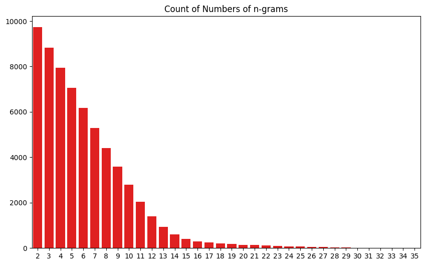

```python
input_output_length = [len(sequence) for sequence in input_output_pair]
count_length = Counter(input_output_length)
fig,ax = plt.subplots(figsize=(10,6))

sns.barplot(x=list(count_length.keys()), y=list(count_length.values()), ax=ax, color='red').set(title='Count of Numbers of n-grams')
plt.show()
```

### SEQUENCING AND PADDING

- Convert sequences of different lengths by padding them to ensure all are the same length.
- Convert the padded sequences to a NumPy array.
- Then, slice the last word as the output where the preceding words are the input.
- Lastly, we will convert the `y` into a one-hot encoded array.

```python
# Determine the maximum sequence length
maxlen = max([len(x) for x in input_output_pair])

# Pad sequences for each set of pairs
input_output_pair_padded = np.array(pad_sequences(input_output_pair, maxlen=maxlen, padding='pre'))

# Print padded sequences for each set of pairs
print(f'Original Data:\n{input_output_pair_padded}\n')
```

```
Original Data:
[[  0   0   0 ...   0  17   1]
 [  0   0   0 ...   0   1  49]
 [  0   0   0 ...   0  49   2]
 ...
 [  0   0   0 ...   7   1 106]
 [  0   0   0 ... 604 112  15]
 [  0   0   0 ...   2  13  81]]
```

**SLICING AND SPLITTING INTO X AND Y VARIABLES**

- Now, we will slice and split the data to X and y for model training and evaluation.

```python
# Separating input and output for the original data
X = input_output_pair_padded[:, :-1]
y = input_output_pair_padded[:, -1]

# Print out examples to showcase the structure
print("Examples of Separated Input and Output Data:\n")

# Print X and y for original data
print("X (Original):")
print(X)
print("\ny (Original):")
print(y)
```

```
Examples of Separated Input and Output Data:

X (Original):
[[  0   0   0 ...   0   0  17]
 [  0   0   0 ...   0   0   1]
 [  0   0   0 ...   0   0  49]
 ...
 [  0   0   0 ... 211   7   1]
 [  0   0   0 ...  16 604 112]
 [  0   0   0 ... 588   2  13]]

y (Original):
[  1  49   2 ... 106  15  81]
```

**CONVERTING Y INTO A ONE-HOT ENCODED ARRAY**

- To convert `y` into a one-hot encoded array, use `to_categorical()` to one-hot encode the target variable `y`.

```python
# Get the total number of words
total_words = len(tokenizer.word_index) + 1

# Convert labels to one-hot encodings
y = utils.to_categorical(y, num_classes=total_words)

# Print the one-hot encoded labels
print("Original Data (y):")
print(y)
```

```
Original Data (y):
[[0. 1. 0. ... 0. 0. 0.]
 [0. 0. 0. ... 0. 0. 0.]
 [0. 0. 1. ... 0. 0. 0.]
 ...
 [0. 0. 0. ... 0. 0. 0.]
 [0. 0. 0. ... 0. 0. 0.]
 [0. 0. 0. ... 0. 0. 0.]]
```

**SPLITTING THE DATA INTO TRAINING AND VALIDATION SETS**

- To ensure that the data used for training does not overfit on the model, we will split the data into train and validation sets using `train_test_split()` with an 80-20 ratio to ensure there is sufficient data for training.
- No test data is created as we will be utilizing the `seed_texts` to test our model's performance and generalization to unseen data.

```python
# Split the training data into training and validation sets
X_train, X_val, y_train, y_val = train_test_split(X, y, test_size=0.2, shuffle=True, random_state=21)

# Print the shapes to verify the split
print("X_train shape:", X_train.shape)
print("y_train shape:", y_train.shape)
print("X_val shape:", X_val.shape)
print("y_val shape:", y_val.shape)
```

```
X_train shape: (50367, 34)
y_train shape: (50367, 1199)
X_val shape: (12592, 34)
y_val shape: (12592, 1199)
```

### TOKENIZE SEED TEXTS FOR MODEL EVALUATION

- To use the `seed_texts` for test data, we will tokenize it and convert the data to sequences for use later.
- After that, we will pad the `seed_texts` as well to ensure that they are all the same length.

```python
# Tokenize seed texts and convert to sequences
tokenized_seed_text = tokenizer.texts_to_sequences(seed_texts)
tokenized_padded_seed_text = np.array(pad_sequences(tokenized_seed_text, maxlen=maxlen-1, padding='pre'))
```

### MODEL BUILDING AND DEVELOPMENT

For recurrent neural networks, we will be exploring various models and approaches to be able to predict the next words when given a set of input texts and sequences. For model building, we will use models like LSTMs and GRU models to evaluate if these models will be able to provide satisfactory performance and generative capabilities.

To solve this RNN task, we will be making use of a few models.

- Simple / Vanilla RNN Model (Baseline Model)
- Long Short-Term Memory (LSTM) Network
- Stacked LSTM + Experimental LSTM Model Variation
- Gated Recurrent Networks (GRUs)
- Stacked GRU + Experimental GRU Model Variation
- Bi-Directional RNNs

Main metrics used for evaluation :

- Training Loss, Validation Loss
- Training Accuracy, Validation Accuracy

### DEFINING CONSTANT VARIABLES USED FOR MODELLING

- Before creating the first model, we will define some constant variables that will be used throughout the model building and development process.
- Some variables include `vocab_size`, `batch_size` and `number of epochs`.

```python
# Defining constant variables for modelling later

# Vocabulary Size
vocab_size = len(tokenizer.word_index) + 1

# Input Length and Shape Variable
input_length = maxlen - 1
input_shape = (input_length,)

# Number of Epochs
epochs = 20

# Batch Size
batch_size = 32
```

### DEFINING FUNCTIONS FOR MODEL FITTING

- Throughout the analysis, we will be leveraging on `EarlyStopping()` and `ReduceLROnPlateau()` when fitting the model to the architecture.
- EarlyStopping() : EarlyStopping() is used to prevent overfitting in the training data as it stops the training process before the model starts fitting the noise in the training data. The patience is set to 10, where training continues for up to 10 epochs and stops after if there are no improvements made.
- ReduceLROnPlateau() : ReduceLROnPlateau() is used to adjust the learning rate dynamically when the metric it monitors stops improving, and in this case would be 'val_loss'.

```python
# Define Early Stopping Function
early_stopping = EarlyStopping(monitor='val_loss', patience=10, restore_best_weights=True)

# Define ReduceLrONPlateau
reduce_lr = ReduceLROnPlateau(monitor='val_loss', patience=10, verbose=1)
```

### MODEL 1 : SIMPLE / VANILLA RNN MODEL (BASELINE)

- A Simple Recurrent Neural Network (RNN) is a fundamental architecture for handling sequential data. It serves as the baseline model due to its simplicity and ease of implementation. This network consists of input, hidden, and output layers, with the hidden layer maintaining a state that captures information from past inputs.
- While Simple RNNs are advantageous for their simplicity and interpretability, they are most suitable for tasks involving shorter sequences and serve as a starting point to establish a performance baseline before exploring more complex models like LSTMs or GRUs, particularly when model simplicity and interpretability are key priorities. Thus, our simple RNN model will serve as a benchmark to reference more complex models later on.

```python
# Simple RNN Model - Baseline Model

# Set vocab size and embedding
embedding_dim = 30

# Building the model
input_layer = Input(shape=(input_length,))
x = Embedding(input_dim=vocab_size, output_dim=embedding_dim, input_length=input_length)(input_layer)

# Adding multiple SimpleRNN layers with dropout for regularization
x = SimpleRNN(units=256, return_sequences=False)(x)
x = Dropout(0.3)(x)

# Output layer
x = Dense(vocab_size, activation='softmax')(x)

# Create the model
baseline = Model(inputs=input_layer, outputs=x, name="SimpleRNN_Baseline")

# Compiling the model
baseline.compile(loss='categorical_crossentropy', optimizer='adam', metrics=['accuracy'])

# Getting the model summary
baseline.summary()
```

```
Model: "SimpleRNN_Baseline"
_________________________________________________________________
 Layer (type)                Output Shape              Param #
=================================================================
 input_1 (InputLayer)        [(None, 34)]              0

 embedding_1 (Embedding)     (None, 34, 30)            35970

 simple_rnn (SimpleRNN)      (None, 256)               73472

 dropout_1 (Dropout)         (None, 256)               0

 dense_1 (Dense)             (None, 1199)              308143

=================================================================
Total params: 417,585
Trainable params: 417,585
Non-trainable params: 0
_________________________________________________________________
```

**FITTING THE DATA TO THE BASELINE MODEL**

Fit the data using `model.fit`. Apply early stopping to the model as well to try and prevent overfitting of data.

```python
# Fit the model
baselineHistory = baseline.fit(X_train, y_train, epochs=epochs, validation_data = (X_val, y_val), batch_size=batch_size, callbacks=[early_stopping, reduce_lr])
```

**EXTRACT THE TRAINING HISTORY OF THE BASELINE MODEL INTO A DICTIONARY**

- Use `.history` to extract the training data from the SimpleRNN model.
- Store the results in a dataframe and use `pd.concat()` to display the results.

```python
baselineHistory = baselineHistory.history
```

```python
# Get model results
result_df = compile_results(baselineHistory, "Baseline_Model_SimpleRNN", 32, result_df)
display(result_df.iloc[0])
```

```
Model Name           Baseline_Model_SimpleRNN
Epochs                                     20
Batch Size                                 32
Train Loss                            1.09404
Val Loss                             1.154362
Train Acc                            0.732404
Val Acc                              0.725619
[Train - Val] Acc                    0.006785
Name: 0, dtype: object
```

**PLOTTING THE LOSS AND ACCURACY CURVE**

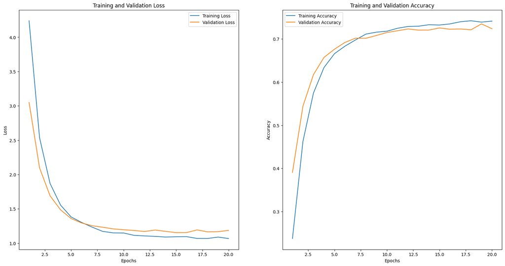

```python
# Plot the loss and accuracy curve
plot_curve(baselineHistory)
plt.show()
```

**TESTING THE MODEL WITH SEED_TEXTS**

```python
predict_next_n_words(model=baseline, tokenizer=tokenizer, sequences=tokenized_padded_seed_text, seed_texts=seed_texts, n=10)
```

```
Original Text: embrace each day
Predicted Text: embrace each day is a unique symphony of love for it is the
Validation Perplexity: 3.276097015551883

Original Text: radiate some
Predicted Text: radiate some enthusiasm and let it be the armor that shields your
Validation Perplexity: 3.276097015551883

Original Text: believe that
Predicted Text: believe that our planet encourages wide open canvases of nature's winds and
Validation Perplexity: 3.276097015551883

Original Text: life's actual purpose is
Predicted Text: life's actual purpose is the driving guiding star for it carries the echoes of
Validation Perplexity: 3.276097015551883

Original Text: dance through each and every
Predicted Text: dance through each and every will brings new opportunities to shine and love in your
Validation Perplexity: 3.276097015551883

Original Text: let your time and energy
Predicted Text: let your time and energy brightly that cuts through doubt halls of your life be
Validation Perplexity: 3.276097015551883

Original Text: every person is
Predicted Text: every person is waves of goodness aspirations and in the fulfillment of your
Validation Perplexity: 3.276097015551883

Original Text: our country Singapore is
Predicted Text: our country Singapore is waves of empathy woven with threads of life and find
Validation Perplexity: 3.276097015551883

Original Text: planet earth is
Predicted Text: planet earth is created by the promise of a brighter tomorrow story and
Validation Perplexity: 3.276097015551883

Original Text: morning and evening would make it
Predicted Text: morning and evening would make it can transform a living proof of your strength and resilience
Validation Perplexity: 3.276097015551883
```

### MODEL 2 : LONG SHORT-TERM MEMORY MODEL

- LSTMs are an advanced type of RNN designed to handle sequence dependency and avoid the long-term dependency problem. They include memory cells that can maintain information in memory for long periods.
- LSTMs use a network of cells with the input gate controlling what information to accept from the current input, forget gate determining what information to forget from the previous state, and the output gate determining what information to output to the next state and the prediction.
- For LSTMs, to run on CuDNN kernels, it requires the activation function to be tanh and recurrent activation of sigmoid. Hence, due to a lack of computational power, I experimented only with these activation and recurrent activation functions.

#### SIMPLE LSTM MODEL LAYERS

- For the LSTM model, we will use one LSTM layer with 256 units to test and evaluate its general performance on the data.
- Based on the results, we will then predict on `seed_texts` data to see how well the model is able to perform.

```python
# LSTM Model

# Set embedding for vocab size
embedding_dim = 30

# Building the model
input_layer = Input(shape=input_shape)
x = Embedding(input_dim=vocab_size, output_dim=embedding_dim, input_length=input_length)(input_layer)
x = LSTM(units=256, return_sequences=False)(x)
x = Dropout(0.3)(x)

# Output Layer
x = Dense(vocab_size, activation='softmax')(x)

# Create the model
lstm = Model(inputs=input_layer, outputs=x, name="Simple_LSTM_Model")

# Compiling the model
lstm.compile(loss='categorical_crossentropy', optimizer='adam', metrics=['accuracy'])

# Getting the model summary
lstm.summary()
```

[output not shown]

**FITTING THE DATA TO THE SIMPLE LSTM MODEL**

Fit the data using `model.fit`. Apply early stopping to the model as well to try and prevent overfitting of data.

```python
# Fit the model
lstmHistory = lstm.fit(X_train, y_train, epochs=epochs, validation_data = (X_val, y_val), batch_size=batch_size, callbacks=[early_stopping, reduce_lr])
```

**EXTRACT THE TRAINING HISTORY OF THE SIMPLE LSTM MODEL INTO A DICTIONARY**

- Use `.history` to extract the training data from the LSTM model.
- Store the results in a dataframe and use `pd.concat()` to display the results.

```python
lstmHistory = lstmHistory.history
```

```python
# Get model results
result_df = compile_results(lstmHistory, "Baseline_Model_LSTM", 32, result_df)
display(result_df.iloc[1])
```

```
Model Name           Baseline_Model_LSTM
Epochs                                20
Batch Size                            32
Train Loss                      0.840206
Val Loss                        1.043199
Train Acc                        0.76973
Val Acc                         0.737055
[Train - Val] Acc               0.032675
Name: 1, dtype: object
```

**PLOTTING THE LOSS AND ACCURACY CURVE**

- The loss and accuracy curve here showed that there was not much overfitting on the loss and accuracy values as the graphs were similar in shape and had similar curvatures.
- However, there is still a small yet noticeable gap between the training and validation loss, indicating that we can apply techniques like LayerNormalization() or increase dropout rate to try and minimize the gap.

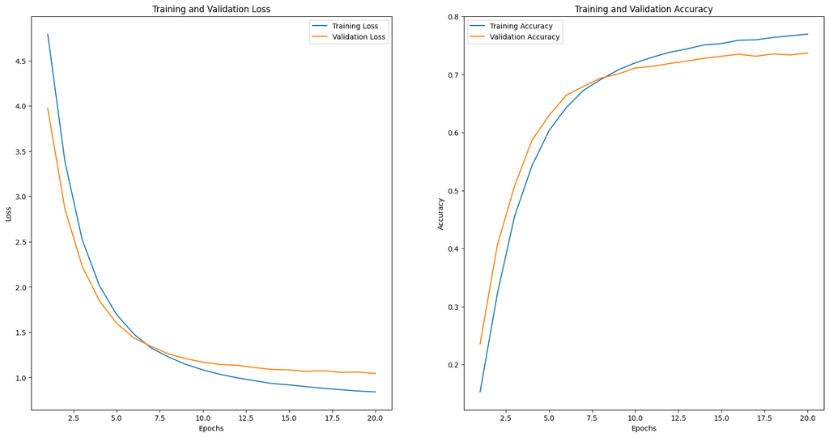

```python
# Plot the loss and accuracy curve
plot_curve(lstmHistory)
plt.show()
```

**TESTING THE MODEL WITH SEED_TEXTS**

```python
predict_next_n_words(model=lstm, tokenizer=tokenizer, sequences=tokenized_padded_seed_text, seed_texts=seed_texts, n=10)
```

```
Original Text: embrace each day
Predicted Text: embrace each day with a heart full of gratitude and laughter be the
Validation Perplexity: 2.838282348528227

Original Text: radiate some
Predicted Text: radiate some peace and the future of our planet and compassion be
Validation Perplexity: 2.838282348528227

Original Text: believe that
Predicted Text: believe that this morning presents to you to a testament to diversity
Validation Perplexity: 2.838282348528227

Original Text: life's actual purpose is
Predicted Text: life's actual purpose is a reminder that the beauty in letting go of what
Validation Perplexity: 2.838282348528227

Original Text: dance through each and every
Predicted Text: dance through each and every we glimpse the soulful song and our aspirations and dreams
Validation Perplexity: 2.838282348528227

Original Text: let your time and energy
Predicted Text: let your time and energy to bukit timah nature reserve's grandeur singapore's nature is a
Validation Perplexity: 2.838282348528227

Original Text: every person is
Predicted Text: every person is a door a testament to its ambition and vision of
Validation Perplexity: 2.838282348528227

Original Text: our country Singapore is
Predicted Text: our country Singapore is a universe the story of kindness and abundance dreams find
Validation Perplexity: 2.838282348528227

Original Text: planet earth is
Predicted Text: planet earth is a victory we can protect the soul of our planet
Validation Perplexity: 2.838282348528227

Original Text: morning and evening would make it
Predicted Text: morning and evening would make it and generosity shape the community of our planet's ecosystems are
Validation Perplexity: 2.838282348528227
```

### CONCLUSION FROM BASELINE LSTM MODEL

- Based on the results provided by the baseline LSTM model, we can see that the sentences still do not make much sense based on human evaluation, hence more still needs to be done to improve the predictions made.
- Looking at the metrics, we see that the validation loss is still relatively high, and we should improve the LSTM model further to reduce the loss and make the sentences more coherent.

### MODEL 1.1 : EXPERIMENTAL LSTM MODEL VARIATION - STACKED LSTM

- Based on the results of the simple LSTM model, we will now experiment with deepening the neural network to determine if a more complex model architecture results in better predictions.
- Some changes made include changing the number of LSTM layers, adding LayerNormalization() and increasing the rate of Dropout.

Modifications Applied to the LSTM Architecture :

```python
# LSTM - Experimental LSTM Model Variation

# Set embedding for vocab size
embedding_dim = 30

# Set layers
lstm_units = [256, 128]

# Building the model
input_layer = Input(shape=input_shape)
x = Embedding(input_dim=vocab_size, output_dim=embedding_dim, input_length=input_length)(input_layer)

# Increasing the number of LSTM layers
for units in lstm_units:
    x = LSTM(units=units, return_sequences=True, activation='tanh', recurrent_activation='sigmoid')(x)
    x = LayerNormalization()(x)
    x = Dropout(0.5)(x)

# Final LSTM layer
x = LSTM(units=lstm_units[-1], return_sequences=False, activation='tanh', recurrent_activation='sigmoid')(x)
x = LayerNormalization()(x)
x = Dropout(0.5)(x)

# Output layer
x = Dense(vocab_size, activation='softmax')(x)

# Create the model
lstm_model_2 = Model(inputs=input_layer, outputs=x, name="LSTM_Model_2")

# Compiling the model
lstm_model_2.compile(loss='categorical_crossentropy', optimizer='adam', metrics=['accuracy'])

# Getting the model summary
lstm_model_2.summary()
```

```
Model: "LSTM_Model_2"
_________________________________________________________________
 Layer (type)                Output Shape              Param #
=================================================================
 input_2 (InputLayer)        [(None, 34)]              0

 embedding_1 (Embedding)     (None, 34, 30)            35970

 lstm_1 (LSTM)               (None, 34, 256)           293888

 layer_normalization (LayerN  (None, 34, 256)          512
 ormalization)

 dropout_1 (Dropout)         (None, 34, 256)           0

 lstm_2 (LSTM)               (None, 34, 128)           197120

 layer_normalization_1 (Laye  (None, 34, 128)          256
 rNormalization)

 dropout_2 (Dropout)         (None, 34, 128)           0

 lstm_3 (LSTM)               (None, 128)               131584

 layer_normalization_2 (Laye  (None, 128)              256
 rNormalization)

 dropout_3 (Dropout)         (None, 128)               0

 dense_1 (Dense)             (None, 1199)              154671

=================================================================
Total params: 814,257
Trainable params: 814,257
Non-trainable params: 0
_________________________________________________________________
```

**FITTING THE DATA TO THE LSTM VARIATION 1 MODEL**

Fit the data using `model.fit`. Apply early stopping to the model as well to try and prevent overfitting of data.

```python
# Fit the model
lstm2History = lstm_model_2.fit(X_train, y_train, epochs=epochs, validation_data = (X_val, y_val), batch_size=batch_size, callbacks=[early_stopping, reduce_lr])
```

**EXTRACT THE TRAINING HISTORY OF THE LSTM VARIATION 1 MODEL INTO A DICTIONARY**

- Use `.history` to extract the training data from the LSTM model.
- Store the results in a dataframe and use `pd.concat()` to display the results.

```python
lstm2History = lstm2History.history
```

```python
# Get model results
result_df = compile_results(lstm2History, "Stacked_LSTM_Model_1", 32, result_df)
display(result_df.iloc[2])
```

```
Model Name           Stacked_LSTM_Model_1
Epochs                                 20
Batch Size                             32
Train Loss                       2.186874
Val Loss                         1.792536
Train Acc                        0.480235
Val Acc                           0.57473
[Train - Val] Acc               -0.094495
Name: 2, dtype: object
```

**PLOTTING THE LOSS AND ACCURACY CURVE**

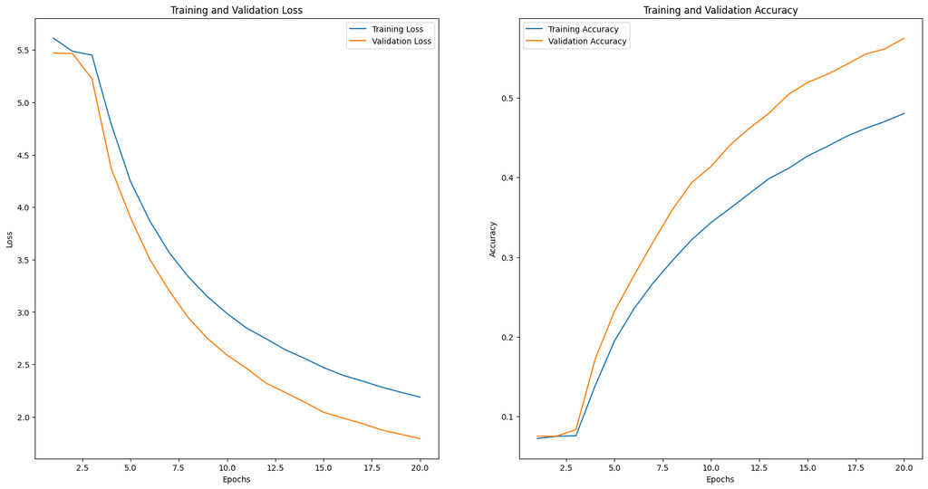

```python
# Plot the loss and accuracy curve
plot_curve(lstm2History)
plt.show()
```

**TESTING THE MODEL WITH SEED_TEXTS**

```python
predict_next_n_words(model=lstm_model_2, tokenizer=tokenizer, sequences=tokenized_padded_seed_text, seed_texts=seed_texts, n=10)
```

```
Original Text: embrace each day
Predicted Text: embrace each day is an investment in your future success bitterness and lands
Validation Perplexity: 6.00466040005689

Original Text: radiate some
Predicted Text: radiate some kindness for it is the truest expression of your dreams
Validation Perplexity: 6.00466040005689

Original Text: believe that
Predicted Text: believe that reverberates within our planet's future of the universe to richness
Validation Perplexity: 6.00466040005689

Original Text: life's actual purpose is
Predicted Text: life's actual purpose is painted with the strokes of life and joy and passion
Validation Perplexity: 6.00466040005689

Original Text: dance through each and every
Predicted Text: dance through each and every day is a step towards witnessing miracles the extraordinary moments
Validation Perplexity: 6.00466040005689

Original Text: let your time and energy
Predicted Text: let your time and energy and uplift within your life for the way for your
Validation Perplexity: 6.00466040005689

Original Text: every person is
Predicted Text: every person is diverse and breathtaking cannot you are a testament to your
Validation Perplexity: 6.00466040005689

Original Text: our country Singapore is
Predicted Text: our country Singapore is a testament to the beauty and richness of nature's palette
Validation Perplexity: 6.00466040005689

Original Text: planet earth is
Predicted Text: planet earth is stronger than you forward with the stories of life and
Validation Perplexity: 6.00466040005689

Original Text: morning and evening would make it
Predicted Text: morning and evening would make it can turn confidence be your guiding star for you are
Validation Perplexity: 6.00466040005689
```

### CONCLUSION FROM STACKED LSTM MODEL

- From the stacked LSTM model, we see that the validation loss is much higher than the baseline model, but many sentences actually make sense here when we evaluate the sentences gramatically.
- Hence, although validation loss increased, the sentences still managed to make sense. We will then proceed to simplify the LSTM model and assess if it helps in text generation.

### MODEL 1.2 : SIMPLIFIED EXPERIMENTAL LSTM MODEL VARIATION

Modifications Applied to the LSTM Architecture :

- Adding LayerNormalization()
- Kept one LSTM layer
- Adding more units to the LSTM layer
- Dropout Rate remained at 0.5

```python
# LSTM Model - Experimental LSTM Model Variation 2

# Set embedding for vocab size
embedding_dim = 30

# Building the model
input_layer = Input(shape=input_shape)
x = Embedding(input_dim=vocab_size, output_dim=embedding_dim, input_length=input_length)(input_layer)
x = LSTM(units=512, return_sequences=False, activation='tanh', recurrent_activation='sigmoid')(x)
x = LayerNormalization()(x)
x = Dropout(0.5)(x)

# Output Layer
x = Dense(vocab_size, activation='softmax')(x)

# Create the model
lstm_model_3 = Model(inputs=input_layer, outputs=x, name="LSTM_Model_3")

# Compiling the model
lstm_model_3.compile(loss='categorical_crossentropy', optimizer='adam', metrics=['accuracy'])

# Getting the model summary
lstm_model_3.summary()
```

```
Model: "LSTM_Model_3"
_________________________________________________________________
 Layer (type)                Output Shape              Param #
=================================================================
 input_7 (InputLayer)        [(None, 34)]              0

 embedding_6 (Embedding)     (None, 34, 30)            35970

 lstm_6 (LSTM)               (None, 512)               1112064

 layer_normalization_4 (Laye  (None, 512)              1024
 rNormalization)

 dropout_8 (Dropout)         (None, 512)               0

 dense_6 (Dense)             (None, 1199)              615087

=================================================================
Total params: 1,764,145
Trainable params: 1,764,145
Non-trainable params: 0
_________________________________________________________________
```

**FITTING THE DATA TO THE LSTM VARIATION 2 MODEL**

Fit the data using `model.fit`. Apply early stopping to the model as well to try and prevent overfitting of data.

```python
# Fit the model
lstm3History = lstm_model_3.fit(X_train, y_train, epochs=epochs, validation_data = (X_val, y_val), batch_size=batch_size, callbacks=[early_stopping, reduce_lr])
```

**EXTRACT THE TRAINING HISTORY OF THE LSTM VARIATION 2 MODEL INTO A DICTIONARY**

- Use `.history` to extract the training data from the LSTM model.
- Store the results in a dataframe and use `pd.concat()` to display the results.

```python
lstm3History = lstm3History.history
```

```python
# Get model results
result_df = compile_results(lstm3History, "Variation_LSTM_Model_2", 32, result_df)
display(result_df.iloc[3])
```

```
Model Name           Variation_LSTM_Model_2
Epochs                                   20
Batch Size                               32
Train Loss                         0.868729
Val Loss                           0.962274
Train Acc                          0.770842
Val Acc                            0.756274
[Train - Val] Acc                  0.014568
Name: 3, dtype: object
```

**PLOTTING THE LOSS AND ACCURACY CURVE**

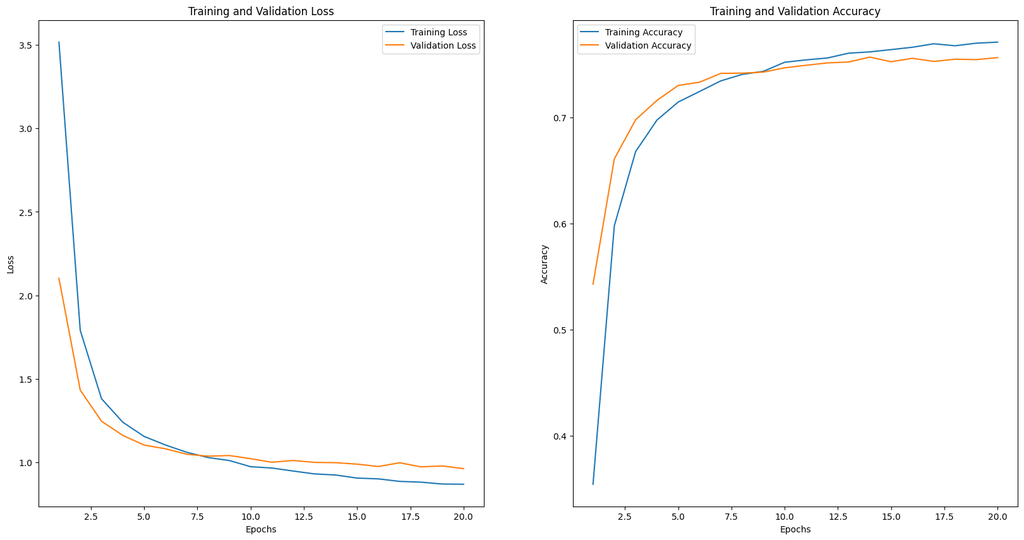

```python
# Plot the loss and accuracy curve
plot_curve(lstm3History)
plt.show()
```

**TESTING THE MODEL WITH SEED_TEXTS**

```python
predict_next_n_words(model=lstm_model_3, tokenizer=tokenizer, sequences=tokenized_padded_seed_text, seed_texts=seed_texts, n=10)
```

```
Original Text: embrace each day
Predicted Text: embrace each day brings new opportunities to shine bright it is the truest
Validation Perplexity: 2.6176413319571377

Original Text: radiate some
Predicted Text: radiate some hope and let it be the beacon that guides your
Validation Perplexity: 2.6176413319571377

Original Text: believe that
Predicted Text: believe that ignites in the hearts of others find their strength and
Validation Perplexity: 2.6176413319571377

Original Text: life's actual purpose is
Predicted Text: life's actual purpose is the driving force behind a fulfilled life story endurance endurance
Validation Perplexity: 2.6176413319571377

Original Text: dance through each and every
Predicted Text: dance through each and every breath this morning inhale peace exhale gratitude be every soundtrack
Validation Perplexity: 2.6176413319571377

Original Text: let your time and energy
Predicted Text: let your time and energy to pursue your dreams and aspirations and in the fulfillment
Validation Perplexity: 2.6176413319571377

Original Text: every person is
Predicted Text: every person is a promise to cherish and protect the future of our
Validation Perplexity: 2.6176413319571377

Original Text: our country Singapore is
Predicted Text: our country Singapore is rich with the fruits of love and joy that reverberates
Validation Perplexity: 2.6176413319571377

Original Text: planet earth is
Predicted Text: planet earth is the canvas of your destiny paint it with intention and
Validation Perplexity: 2.6176413319571377

Original Text: morning and evening would make it
Predicted Text: morning and evening would make it difference singapore's nature is a sanctuary of serenity within you
Validation Perplexity: 2.6176413319571377
```

### CONCLUSION FROM SIMPLIFIED LSTM MODEL VARIATION

- From this model, we see that the perplexity score is much better, indicating that it is more confident in making more accurate predictions, and the validation loss is also lower at 0.96.
- Based on visual inspection, the number of sentences that make sense has also increased, indicating that this model was better able to generate logical sentences compared to the two previous LSTM model variations, thus showing that this model is better in terms of text generation.
- However, we will continue to look at other models and assess if better results can be achieved.

### MODEL 2 : GATED RECURRENT UNIT MODEL (GRU)

- Gated Recurrent Unit Model is designed to mitigate the vanishing gradient problem, capturing dependencies in sequential data. Compared to LSTM, GRU has a simpler structure with two main gates : reset gate and update gate.
- For the reset gate, it controls how much past information to forget, and the update gate decides how much of the new information to incorporate into the current state.
- For GRUs, this model is less computationally expensive than LSTMs but can still perform effectively on text generation tasks.

**BUILDING A SIMPLE GRU MODEL TO EVALUATE PERFORMANCE**

```python
# GRU Model

# Set embedding for vocab size
embedding_dim = 30

# Building the model
input_layer = Input(shape=input_shape)
x = Embedding(input_dim=vocab_size, output_dim=embedding_dim, input_length=input_length)(input_layer)

# GRU Layer
x = GRU(256, return_sequences=False, activation='tanh', recurrent_activation='sigmoid')(x)
x = LayerNormalization()(x)
x = Dropout(0.5)(x)

# Output Layer
x = Dense(vocab_size, activation='softmax')(x)

# Create the model
gru_model = Model(inputs=input_layer, outputs=x, name="GRU_Model")

# Compiling the model
gru_model.compile(loss='categorical_crossentropy', optimizer='adam', metrics=['accuracy'])

# Getting the model summary
gru_model.summary()
```

```
Model: "GRU_Model"
_________________________________________________________________
 Layer (type)                Output Shape              Param #
=================================================================
 input_2 (InputLayer)        [(None, 34)]              0

 embedding_2 (Embedding)     (None, 34, 30)            35970

 gru_1 (GRU)                 (None, 256)               221184

 layer_normalization (LayerN  (None, 256)              512
 ormalization)

 dropout_2 (Dropout)         (None, 256)               0

 dense_2 (Dense)             (None, 1199)              308143

=================================================================
Total params: 565,809
Trainable params: 565,809
Non-trainable params: 0
_________________________________________________________________
```

**FITTING THE DATA TO THE GRU MODEL**

Fit the data using `model.fit`. Apply early stopping to the model as well to try and prevent overfitting of data.

```python
# Fit the model
gruModelHistory = gru_model.fit(X_train, y_train, epochs=epochs, validation_data = (X_val, y_val), batch_size=batch_size, callbacks=[early_stopping, reduce_lr])
```

**EXTRACT THE TRAINING HISTORY OF THE GRU MODEL INTO A DICTIONARY**

- Use `.history` to extract the training data from the GRU model.
- Store the results in a dataframe and use `pd.concat()` to display the results.

```python
gruModelHistory = gruModelHistory.history
```

```python
# Get model results
result_df = compile_results(gruModelHistory, "GRU_Baseline_Model", 32, result_df)
display(result_df.iloc[4])
```

[output not shown]

**PLOTTING THE LOSS AND ACCURACY CURVE**

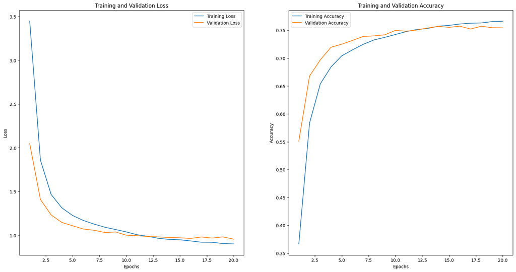

```python
# Plot the loss and accuracy curve
plot_curve(gruModelHistory)
plt.show()
```

**TESTING THE MODEL WITH SEED_TEXTS**

```python
predict_next_n_words(model=gru_model, tokenizer=tokenizer, sequences=tokenized_padded_seed_text, seed_texts=seed_texts, n=10)
```

```
Original Text: embrace each day
Predicted Text: embrace each day brings new opportunities to shine for it is the treasure
Validation Perplexity: 2.598495051893743

Original Text: radiate some
Predicted Text: radiate some love and let go of what no longer serves you
Validation Perplexity: 2.598495051893743

Original Text: believe that
Predicted Text: believe that fuels your progress and innovation vision of tomorrow for they
Validation Perplexity: 2.598495051893743

Original Text: life's actual purpose is
Predicted Text: life's actual purpose is the foundation of every action and decision decision the the
Validation Perplexity: 2.598495051893743

Original Text: dance through each and every
Predicted Text: dance through each and every act of conservation is a legacy of love for our
Validation Perplexity: 2.598495051893743

Original Text: let your time and energy
Predicted Text: let your time and energy that shields your heart free from burdens burdens the perfume
Validation Perplexity: 2.598495051893743

Original Text: every person is
Predicted Text: every person is its burdens the heart to heal and transform to connect
Validation Perplexity: 2.598495051893743

Original Text: our country Singapore is
Predicted Text: our country Singapore is written with the chapters of our experiences and choices we
Validation Perplexity: 2.598495051893743

Original Text: planet earth is
Predicted Text: planet earth is a brushstroke a stroke of the brush a deliberate mark
Validation Perplexity: 2.598495051893743

Original Text: morning and evening would make it
Predicted Text: morning and evening would make it extraordinary moments that defy logic and touch the soul of
Validation Perplexity: 2.598495051893743
```

### CONCLUSION FROM BASELINE GRU MODEL

- The baseline GRU model here clearly performs the best of all the models so far, as it is able to provide the lowest validation perplexity score, and based on visual inspection and validation loss, we can confidently say that this model is able to perform the best of all the models tested beforehand.
- Looking at this model, we can now proceed to experiment with model variations of GRU to see if it is able to provide us more promising results.

### MODEL 2.1 : EXPERIMENTAL GRU MODEL VARIATION - STACKED GRU

- Based on the results from the Simple GRU Model, we see that the model performed fairly well in predicting the next 10 words for most of the input texts.
- However, we want to evaluate if making a deeper GRU model will enable the model to perform better with more layers and changes to the number of units and dropout rates.

Changes to the GRU Architecture:

```python
# GRU Model - Experimental GRU Model Variation

# Set embedding for vocab size
embedding_dim = 30

# Building the model
input_layer = Input(shape=input_shape)
x = Embedding(input_dim=vocab_size, output_dim=embedding_dim, input_length=input_length)(input_layer)

# GRU Layer
x = GRU(256, return_sequences=True, activation='tanh', recurrent_activation='sigmoid')(x)
x = LayerNormalization()(x)
x = Dropout(0.5)(x)

x = GRU(128, return_sequences=False, activation='tanh', recurrent_activation='sigmoid')(x)
x = LayerNormalization()(x)
x = Dropout(0.5)(x)

# Output Layer
x = Dense(vocab_size, activation='softmax')(x)

# Create the model
gru_model_2 = Model(inputs=input_layer, outputs=x, name="GRU_Model_2")

# Compiling the model
gru_model_2.compile(loss='categorical_crossentropy', optimizer='adam', metrics=['accuracy'])

# Getting the model summary
gru_model_2.summary()
```

```
Model: "GRU_Model_2"
_________________________________________________________________
 Layer (type)                Output Shape              Param #
=================================================================
 input_9 (InputLayer)        [(None, 34)]              0

 embedding_8 (Embedding)     (None, 34, 30)            35970

 gru_1 (GRU)                 (None, 34, 256)           221184

 layer_normalization_6 (Laye  (None, 34, 256)          512
 rNormalization)

 dropout_10 (Dropout)        (None, 34, 256)           0

 gru_2 (GRU)                 (None, 128)               148224

 layer_normalization_7 (Laye  (None, 128)              256
 rNormalization)

 dropout_11 (Dropout)        (None, 128)               0

 dense_8 (Dense)             (None, 1199)              154671

=================================================================
Total params: 560,817
Trainable params: 560,817
Non-trainable params: 0
_________________________________________________________________
```

**FITTING THE DATA TO THE COMPLEX GRU MODEL**

Fit the data using `model.fit`. Apply early stopping to the model as well to try and prevent overfitting of data.

```python
# Fit the model
gruModel_2History = gru_model_2.fit(X_train, y_train, epochs=epochs, validation_data = (X_val, y_val), batch_size=batch_size, callbacks=[early_stopping, reduce_lr])
```

**EXTRACT THE TRAINING HISTORY OF THE MORE COMPLEX GRU MODEL INTO A DICTIONARY**

- Use `.history` to extract the training data from the GRU model.
- Store the results in a dataframe and use `pd.concat()` to display the results.

```python
gruModel_2History = gruModel_2History.history
```

```python
# Get model results
result_df = compile_results(gruModel_2History, "Stacked_GRU_Model", 32, result_df)
display(result_df.iloc[5])
```

```
Model Name           Stacked_GRU_Model
Epochs                              20
Batch Size                          32
Train Loss                    1.209042
Val Loss                      1.027578
Train Acc                     0.711279
Val Acc                       0.741582
[Train - Val] Acc            -0.030303
Name: 5, dtype: object
```

**PLOTTING THE LOSS AND ACCURACY CURVE**

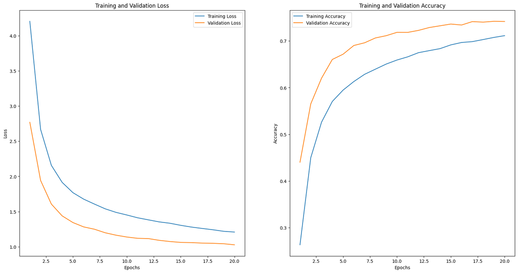

```python
# Plot the loss and accuracy curve
plot_curve(gruModel_2History)
plt.show()
```

**TESTING THE MODEL WITH SEED_TEXTS**

```python
predict_next_n_words(model=gru_model_2, tokenizer=tokenizer, sequences=tokenized_padded_seed_text, seed_texts=seed_texts, n=10)
```

```
Original Text: embrace each day
Predicted Text: embrace each day is a canvas for new beginnings and binds the path
Validation Perplexity: 2.794289185584389

Original Text: radiate some
Predicted Text: radiate some kindness and become a light in the world creating waves
Validation Perplexity: 2.794289185584389

Original Text: believe that
Predicted Text: believe that resonates in the hearts of others find their way by
Validation Perplexity: 2.794289185584389

Original Text: life's actual purpose is
Predicted Text: life's actual purpose is alive and thriving a testament to your indomitable spirit and
Validation Perplexity: 2.794289185584389

Original Text: dance through each and every
Predicted Text: dance through each and every day is a precious gift on you can give to
Validation Perplexity: 2.794289185584389

Original Text: let your time and energy
Predicted Text: let your time and energy is painted with the strokes of our intentions and actions
Validation Perplexity: 2.794289185584389

Original Text: every person is
Predicted Text: every person is encounter carries a story worthy of empathy of your understanding
Validation Perplexity: 2.794289185584389

Original Text: our country Singapore is
Predicted Text: our country Singapore is a celebration of the beauty in transitions in the ebb
Validation Perplexity: 2.794289185584389

Original Text: planet earth is
Predicted Text: planet earth is a classroom where we learn to love and let go
Validation Perplexity: 2.794289185584389

Original Text: morning and evening would make it
Predicted Text: morning and evening would make it sets your spirit free from bitterness and resentment a path
Validation Perplexity: 2.794289185584389
```

### CONCLUSION FROM STACKED GRU MODEL

- For this model, we can also see that it performed relatively well in comparison to the baseline GRU model as it has sentences that still make sense.
- However, its validation perplexity score is higher, indicating that the model is less confident in its predictions compared to when using the baseline model.
- So, the stacked GRU model is not optimal for text generation.

### MODEL 3 : BI-DIRECTIONAL RNN - BRNN

- BiRNNs involve two RNNs stacked on top of each other. One processes the data in a forward direction, and the other processes the data in a backward direction.
- Using bi-directional sequences, it enables the BIRNN model to capture information from the past and future context of each time step.
- For bi-directional RNN, we will be testing it on LSTM layers and GRU layers.

Forward Pass:

- The input sequence is fed into the network in the usual left-to-right order. At each time step, the network computes hidden states using the current input and the previous hidden state. These forward hidden states capture information from the beginning of the sequence up to the current position.

Backward Pass:

- At the same time, a separate copy of the input sequence is processed in reverse order from right to left. At each time step in the backward pass, the network computes backward hidden states using the current reversde input and the previous backward hidden state. These backward hidden states capture information from the end of the sequence up to the current position but in reverse.

For this model, we will be testing BRNN with LSTM and GRU layers, with single layering and stacked models as well.

### LSTM LAYER

**SIMPLE BRNN | LSTM LAYER**

```python
# BRNN Model | LSTM Layer

# Set embedding for vocab size
embedding_dim = 30

# Building the model
input_layer = Input(shape=input_shape)
x = Embedding(input_dim=vocab_size, output_dim=embedding_dim, input_length=input_length)(input_layer)

# LSTM Layer
x = Bidirectional(LSTM(256, return_sequences=False, activation='tanh', recurrent_activation='sigmoid'))(x)
x = LayerNormalization()(x)
x = Dropout(0.3)(x)

# Output Layer
x = Dense(vocab_size, activation='softmax')(x)

# Create the model
bidirectional_lstm_model = Model(inputs=input_layer, outputs=x, name="BiDirectional_LSTM_Model")

# Compiling the model
bidirectional_lstm_model.compile(loss='categorical_crossentropy', optimizer='adam', metrics=['accuracy'])

# Getting the model summary
bidirectional_lstm_model.summary()
```

```
Model: "BiDirectional_LSTM_Model"
_________________________________________________________________
 Layer (type)                Output Shape              Param #
=================================================================
 input_12 (InputLayer)       [(None, 34)]              0

 embedding_11 (Embedding)    (None, 34, 30)            35970

 bidirectional_1 (Bidirectio  (None, 512)              587776
 nal)

 layer_normalization_9 (Laye  (None, 512)              1024
 rNormalization)

 dropout_13 (Dropout)        (None, 512)               0

 dense_10 (Dense)            (None, 1199)              615087

=================================================================
Total params: 1,239,857
Trainable params: 1,239,857
Non-trainable params: 0
_________________________________________________________________
```

**FITTING THE DATA TO THE BRNN-LSTM MODEL**

Fit the data using `model.fit`. Apply early stopping to the model as well to try and prevent overfitting of data.

```python
# Fit the model
bidirectional_lstm_modelHistory = bidirectional_lstm_model.fit(X_train, y_train, epochs=epochs, validation_data = (X_val, y_val), batch_size=batch_size, callbacks=[early_stopping, reduce_lr])
```

**EXTRACT THE TRAINING HISTORY OF THE MORE SIMPLE BRNN-LSTM MODEL INTO A DICTIONARY**

- Use `.history` to extract the training data from the BRNN-LSTM model.
- Store the results in a dataframe and use `pd.concat()` to display the results.

```python
bidirectional_lstm_modelHistory = bidirectional_lstm_modelHistory.history
```

```python
# Get model results
result_df = compile_results(bidirectional_lstm_modelHistory, "BRNN_LSTM_Model", 32, result_df)
display(result_df.iloc[6])
```

```
Model Name           BRNN_LSTM_Model
Epochs                            20
Batch Size                        32
Train Loss                  0.852364
Val Loss                    0.961909
Train Acc                   0.770604
Val Acc                     0.753494
[Train - Val] Acc            0.01711
Name: 6, dtype: object
```

**PLOTTING THE LOSS AND ACCURACY CURVE**

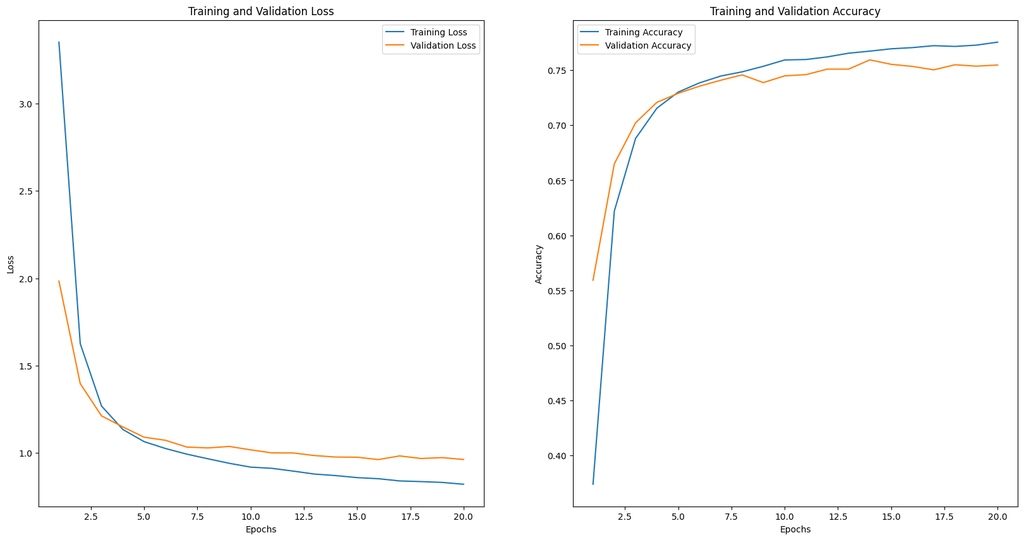

```python
# Plot the loss and accuracy curve
plot_curve(bidirectional_lstm_modelHistory)
plt.show()
```

**TESTING THE MODEL WITH SEED_TEXTS**

```python
predict_next_n_words(model=bidirectional_lstm_model, tokenizer=tokenizer, sequences=tokenized_padded_seed_text, seed_texts=seed_texts, n=10)
```

```
Original Text: embrace each day
Predicted Text: embrace each day this morning find the energy to pursue your dreams and
Validation Perplexity: 2.6179430989570434

Original Text: radiate some
Predicted Text: radiate some hope for it is the beacon that guides your way
Validation Perplexity: 2.6179430989570434

Original Text: believe that
Predicted Text: believe that this morning offers the promise of a fresh start and
Validation Perplexity: 2.6179430989570434

Original Text: life's actual purpose is
Predicted Text: life's actual purpose is the foundation the legacy of love and compassion you leave
Validation Perplexity: 2.6179430989570434

Original Text: dance through each and every
Predicted Text: dance through each and every challenge faced is an opportunity an opportunity for growth for
Validation Perplexity: 2.6179430989570434

Original Text: let your time and energy
Predicted Text: let your time and energy will follow is a mark of respect for our planet
Validation Perplexity: 2.6179430989570434

Original Text: every person is
Predicted Text: every person is its magic you encounter bad is a story for others
Validation Perplexity: 2.6179430989570434

Original Text: our country Singapore is
Predicted Text: our country Singapore is the gateway to a peaceful heart and this that you
Validation Perplexity: 2.6179430989570434

Original Text: planet earth is
Predicted Text: planet earth is diverse and breathtaking views singapore's nature is diverse and breathtaking
Validation Perplexity: 2.6179430989570434

Original Text: morning and evening would make it
Predicted Text: morning and evening would make it is contagious and boundless power the boundless symphony of the
Validation Perplexity: 2.6179430989570434
```

### CONCLUSION FROM THE BRNN - LSTM MODEL

- For this model, output-wise it perfomed quite well with relatively sensible outputs. However, the validation perplexity score is still not as good when compared to the GRU model.
- This disparity could indicate that having good metrics does not necessarily mean that the text generation outputs is better.
- However, we will still continue investigating other models for now to truly determine which model offers the best balance between good metrics and good text generation.

**STACKED BRNN | LSTM LAYER**

```python
# BRNN Model | LSTM Layer

# Set embedding for vocab size
embedding_dim = 30

# Building the model
input_layer = Input(shape=input_shape)
x = Embedding(input_dim=vocab_size, output_dim=embedding_dim, input_length=input_length)(input_layer)

# LSTM Layer
x = LSTM(256, return_sequences=True)(x)
x = Bidirectional(LSTM(128, return_sequences=False, activation='tanh', recurrent_activation='sigmoid'))(x)
x = LayerNormalization()(x)
x = Dropout(0.3)(x)

# Output Layer
x = Dense(vocab_size, activation='softmax')(x)

# Create the model
bidirectional_stacked_lstm_model = Model(inputs=input_layer, outputs=x, name="BiDirectional_Stacked_LSTM_Model")

# Compiling the model
bidirectional_stacked_lstm_model.compile(loss='categorical_crossentropy', optimizer='adam', metrics=['accuracy'])

# Getting the model summary
bidirectional_stacked_lstm_model.summary()
```

```
Model: "BiDirectional_Stacked_LSTM_Model"
_________________________________________________________________
 Layer (type)                Output Shape              Param #
=================================================================
 input_13 (InputLayer)       [(None, 34)]              0

 embedding_12 (Embedding)    (None, 34, 30)            35970

 lstm_8 (LSTM)               (None, 34, 256)           293888

 bidirectional_2 (Bidirectio  (None, 256)              394240
 nal)

 layer_normalization_10 (Lay  (None, 256)              512
 erNormalization)

 dropout_14 (Dropout)        (None, 256)               0

 dense_11 (Dense)            (None, 1199)              308143

=================================================================
Total params: 1,032,753
Trainable params: 1,032,753
Non-trainable params: 0
_________________________________________________________________
```

**FITTING THE DATA TO THE STACKED BRNN-LSTM MODEL**

Fit the data using `model.fit`. Apply early stopping to the model as well to try and prevent overfitting of data.

```python
# Fit the model
bidirectional_stacked_lstm_modelHistory = bidirectional_stacked_lstm_model.fit(X_train, y_train, epochs=epochs, validation_data = (X_val, y_val), batch_size=batch_size, callbacks=[early_stopping, reduce_lr])
```

**EXTRACT THE TRAINING HISTORY OF THE MORE STACKED BRNN-LSTM MODEL INTO A DICTIONARY**

- Use `.history` to extract the training data from the Stacked BRNN-LSTM model.
- Store the results in a dataframe and use `pd.concat()` to display the results.

```python
bidirectional_stacked_lstm_modelHistory = bidirectional_stacked_lstm_modelHistory.history
```

```python
# Get model results
result_df = compile_results(bidirectional_stacked_lstm_modelHistory, "BRNN_Stacked_LSTM_Model", 32, result_df)
display(result_df.iloc[7])
```

```
Model Name           BRNN_Stacked_LSTM_Model
Epochs                                    20
Batch Size                                32
Train Loss                          0.961295
Val Loss                            1.130027
Train Acc                           0.745151
Val Acc                             0.717916
[Train - Val] Acc                   0.027234
Name: 7, dtype: object
```

**PLOTTING THE LOSS AND ACCURACY CURVE**

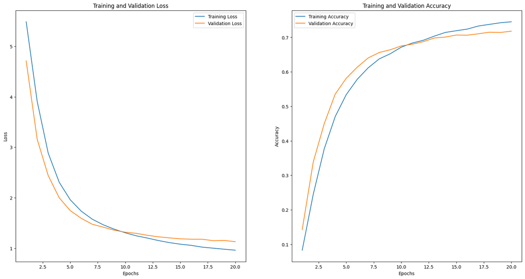

```python
# Plot the loss and accuracy curve
plot_curve(bidirectional_stacked_lstm_modelHistory)
plt.show()
```

**TESTING THE MODEL WITH SEED_TEXTS**

```python
predict_next_n_words(model=bidirectional_stacked_lstm_model, tokenizer=tokenizer, sequences=tokenized_padded_seed_text, seed_texts=seed_texts, n=10)
```

```
Original Text: embrace each day
Predicted Text: embrace each day brighter serenity singapore's tranquility is a treasure trove and bukit
Validation Perplexity: 3.09574136365944

Original Text: radiate some
Predicted Text: radiate some compassion for it is the mark of a truly beautiful
Validation Perplexity: 3.09574136365944

Original Text: believe that
Predicted Text: believe that light in the hearts of others we witness the freedom
Validation Perplexity: 3.09574136365944

Original Text: life's actual purpose is
Predicted Text: life's actual purpose is a gateway to a brighter future of our planet embrace
Validation Perplexity: 3.09574136365944

Original Text: dance through each and every
Predicted Text: dance through each and every thought and gratitude is a resilience a life's course to
Validation Perplexity: 3.09574136365944

Original Text: let your time and energy
Predicted Text: let your time and energy to pursue your dreams and aspirations of smiles and warmth
Validation Perplexity: 3.09574136365944

Original Text: every person is
Predicted Text: every person is cherished what no longer serves you of the pulse of
Validation Perplexity: 3.09574136365944

Original Text: our country Singapore is
Predicted Text: our country Singapore is an investment an investment in a brighter future in the
Validation Perplexity: 3.09574136365944

Original Text: planet earth is
Predicted Text: planet earth is a tapestry of laughter for the gift of our planet
Validation Perplexity: 3.09574136365944

Original Text: morning and evening would make it
Predicted Text: morning and evening would make it can turn dreams into reality of becoming a vibrant and
Validation Perplexity: 3.09574136365944
```

### CONCLUSION FROM THE STACKED BRNN - LSTM MODEL

- From the model, we see that while some sentences do make sense language-wise, the second half of the sentences do not really make as much sense logically if you combine them with the first half of the sentence.
- Hence, this could explain why the perplexity score is higher at 3.09, indicating that the model is not very confident in generating text accurately for this model.

### GRU LAYER

**SIMPLE BRNN | GRU LAYER**

```python
# BRNN Model | GRU Layer

# Set embedding for vocab size
embedding_dim = 30

# Building the model
input_layer = Input(shape=input_shape)
x = Embedding(input_dim=vocab_size, output_dim=embedding_dim, input_length=input_length)(input_layer)

# GRU Layer
x = Bidirectional(GRU(256, return_sequences=False, activation='tanh', recurrent_activation='sigmoid'))(x)
x = LayerNormalization()(x)
x = Dropout(0.3)(x)

# Output Layer
x = Dense(vocab_size, activation='softmax')(x)

# Create the model
bidirectional_gru_model = Model(inputs=input_layer, outputs=x, name="BiDirectional_GRU_Model")

# Compiling the model
bidirectional_gru_model.compile(loss='categorical_crossentropy', optimizer='adam', metrics=['accuracy'])

# Getting the model summary
bidirectional_gru_model.summary()
```

```
Model: "BiDirectional_GRU_Model"
_________________________________________________________________
 Layer (type)                Output Shape              Param #
=================================================================
 input_15 (InputLayer)       [(None, 34)]              0

 embedding_14 (Embedding)    (None, 34, 30)            35970

 bidirectional_4 (Bidirectio  (None, 512)              442368
 nal)

 layer_normalization_11 (Lay  (None, 512)              1024
 erNormalization)

 dropout_16 (Dropout)        (None, 512)               0

 dense_13 (Dense)            (None, 1199)              615087

=================================================================
Total params: 1,094,449
Trainable params: 1,094,449
Non-trainable params: 0
_________________________________________________________________
```

**FITTING THE DATA TO THE SIMPLE BRNN-GRU MODEL**

Fit the data using `model.fit`. Apply early stopping to the model as well to try and prevent overfitting of data.

```python
# Fit the model
bidirectional_gru_modelHistory = bidirectional_gru_model.fit(X_train, y_train, epochs=epochs, validation_data = (X_val, y_val), batch_size=batch_size, callbacks=[early_stopping, reduce_lr])
```

**EXTRACT THE TRAINING HISTORY OF THE MORE SIMPLE BRNN-GRU MODEL INTO A DICTIONARY**

- Use `.history` to extract the training data from the Simple BRNN-GRU model.
- Store the results in a dataframe and use `pd.concat()` to display the results.

```python
bidirectional_gru_modelHistory = bidirectional_gru_modelHistory.history
```

```python
# Get model results
result_df = compile_results(bidirectional_gru_modelHistory, "BRNN_GRU_Model", 32, result_df)
display(result_df.iloc[8])
```

```
Model Name           BRNN_GRU_Model
Epochs                           20
Batch Size                       32
Train Loss                 0.842767
Val Loss                    0.96759
Train Acc                  0.772331
Val Acc                    0.759927
[Train - Val] Acc          0.012404
Name: 8, dtype: object
```

**PLOTTING THE LOSS AND ACCURACY CURVE**

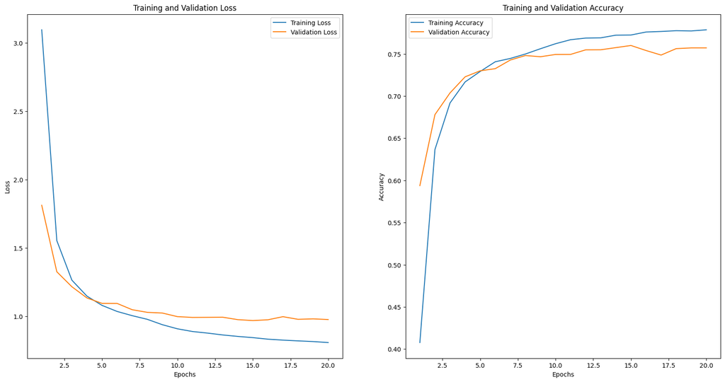

```python
# Plot the loss and accuracy curve
plot_curve(bidirectional_gru_modelHistory)
plt.show()
```

**TESTING THE MODEL WITH SEED_TEXTS**

```python
predict_next_n_words(model=bidirectional_gru_model, tokenizer=tokenizer, sequences=tokenized_padded_seed_text, seed_texts=seed_texts, n=10)
```

```
Original Text: embrace each day
Predicted Text: embrace each day is a canvas for new beginnings of fresh opportunities that
Validation Perplexity: 2.6514430367190696

Original Text: radiate some
Predicted Text: radiate some authenticity for it is the essence of true beauty resides
Validation Perplexity: 2.6514430367190696

Original Text: believe that
Predicted Text: believe that reverberates in the heart spreading warmth and happiness far and
Validation Perplexity: 2.6514430367190696

Original Text: life's actual purpose is
Predicted Text: life's actual purpose is a step towards witnessing miracles the extraordinary moments that defy
Validation Perplexity: 2.6514430367190696

Original Text: dance through each and every
Predicted Text: dance through each and every day brings new opportunities to shine bright peace and the
Validation Perplexity: 2.6514430367190696

Original Text: let your time and energy
Predicted Text: let your time and energy to the universe and let it flow through your being
Validation Perplexity: 2.6514430367190696

Original Text: every person is
Predicted Text: every person is the soul from its burdens and adventures singapore's wildlife is
Validation Perplexity: 2.6514430367190696

Original Text: our country Singapore is
Predicted Text: our country Singapore is palpable essence of true beauty resides within you it's a
Validation Perplexity: 2.6514430367190696

Original Text: planet earth is
Predicted Text: planet earth is the energy that propels you forward is a victory on
Validation Perplexity: 2.6514430367190696

Original Text: morning and evening would make it
Predicted Text: morning and evening would make it holds the preciousness of life story thrive and flourish that
Validation Perplexity: 2.6514430367190696
```

### CONCLUSION FROM THE BRNN - GRU MODEL

- From the model, we can see that the first few sentences do make sense, metrics-wise and from self-evaluation. However, it still makes mistakes and generates incoherent texts that do not make sense.
- To improve the text generation, modifications may need to be made to the model, perhaps adding more layers and changing the number of units in the GRU layer.

**STACKED BRNN | GRU LAYER**

```python
# BRNN Model | GRU Layer

# Set embedding for vocab size
embedding_dim = 30

# Building the model
input_layer = Input(shape=input_shape)
x = Embedding(input_dim=vocab_size, output_dim=embedding_dim, input_length=input_length)(input_layer)

# GRU Layer
x = GRU(256, return_sequences=True)(x)
x = Bidirectional(GRU(128, return_sequences=False, activation='tanh', recurrent_activation='sigmoid'))(x)
x = LayerNormalization()(x)
x = Dropout(0.3)(x)

# Output Layer
x = Dense(vocab_size, activation='softmax')(x)

# Create the model
bidirectional_stacked_gru_model = Model(inputs=input_layer, outputs=x, name="BiDirectional_Stacked_GRU_Model")

# Compiling the model
bidirectional_stacked_gru_model.compile(loss='categorical_crossentropy', optimizer='adam', metrics=['accuracy'])

# Getting the model summary
bidirectional_stacked_gru_model.summary()
```

```
Model: "BiDirectional_Stacked_GRU_Model"
_________________________________________________________________
 Layer (type)                Output Shape              Param #
=================================================================
 input_16 (InputLayer)       [(None, 34)]              0

 embedding_15 (Embedding)    (None, 34, 30)            35970

 gru_6 (GRU)                 (None, 34, 256)           221184

 bidirectional_5 (Bidirectio  (None, 256)              296448
 nal)

 layer_normalization_12 (Lay  (None, 256)              512
 erNormalization)

 dropout_17 (Dropout)        (None, 256)               0

 dense_14 (Dense)            (None, 1199)              308143

=================================================================
Total params: 862,257
Trainable params: 862,257
Non-trainable params: 0
_________________________________________________________________
```

**FITTING THE DATA TO THE STACKED BRNN-GRU MODEL**

Fit the data using `model.fit`. Apply early stopping to the model as well to try and prevent overfitting of data.

```python
# Fit the model
bidirectional_stacked_gru_modelHistory = bidirectional_stacked_gru_model.fit(X_train, y_train, epochs=epochs, validation_data = (X_val, y_val), batch_size=batch_size, callbacks=[early_stopping, reduce_lr])
```

**EXTRACT THE TRAINING HISTORY OF THE MORE STACKED BRNN-GRU MODEL INTO A DICTIONARY**

- Use `.history` to extract the training data from the Stacked BRNN-GRU model.
- Store the results in a dataframe and use `pd.concat()` to display the results.

```python
bidirectional_stacked_gru_modelHistory = bidirectional_stacked_gru_modelHistory.history
```

```python
# Get model results
result_df = compile_results(bidirectional_stacked_gru_modelHistory, "BRNN_Stacked_GRU_Model", 32, result_df)
display(result_df.iloc[9])
```

```
Model Name           BRNN_Stacked_GRU_Model
Epochs                                   20
Batch Size                               32
Train Loss                         0.866061
Val Loss                           0.994902
Train Acc                          0.771696
Val Acc                            0.753177
[Train - Val] Acc                  0.018519
Name: 9, dtype: object
```

**PLOTTING THE LOSS AND ACCURACY CURVE**

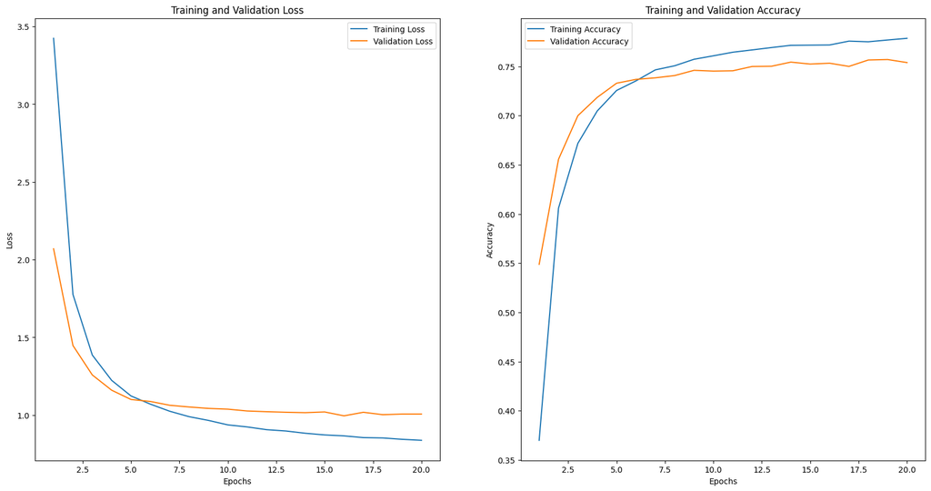

```python
# Plot the loss and accuracy curve
plot_curve(bidirectional_stacked_gru_modelHistory)
plt.show()
```

**TESTING THE MODEL WITH SEED_TEXTS**

```python
predict_next_n_words(model=bidirectional_stacked_gru_model, tokenizer=tokenizer, sequences=tokenized_padded_seed_text, seed_texts=seed_texts, n=10)
```

```
Original Text: embrace each day
Predicted Text: embrace each day filled with endless possibilities for this morning paints the sky
Validation Perplexity: 2.735654366216212

Original Text: radiate some
Predicted Text: radiate some resilience and let it be the fortress of your spirit
Validation Perplexity: 2.735654366216212

Original Text: believe that
Predicted Text: believe that pulse with life's vitality singapore's nature is a sanctuary within
Validation Perplexity: 2.735654366216212

Original Text: life's actual purpose is
Predicted Text: life's actual purpose is the driving force of your journey a tale worth telling
Validation Perplexity: 2.735654366216212

Original Text: dance through each and every
Predicted Text: dance through each and every moment of this morning let gratitude illuminate your soul filling
Validation Perplexity: 2.735654366216212

Original Text: let your time and energy
Predicted Text: let your time and energy of encouragement is a beacon a beacon of light a
Validation Perplexity: 2.735654366216212

Original Text: every person is
Predicted Text: every person is a promise to safeguard the future of our planet encourages
Validation Perplexity: 2.735654366216212

Original Text: our country Singapore is
Predicted Text: our country Singapore is an opportunity for growth and learning for evolving into a
Validation Perplexity: 2.735654366216212

Original Text: planet earth is
Predicted Text: planet earth is a promise to cherish and protect the future of our
Validation Perplexity: 2.735654366216212

Original Text: morning and evening would make it
Predicted Text: morning and evening would make it brings new opportunities to shine any brightly that others find
Validation Perplexity: 2.735654366216212
```

### PERFORMING MODEL SELECTION FOR BEST MODEL

- Upon training the various RNN models, we will be deciding which of the models to hypertune to be our model.
- Based on the results below, we see that our `gru_Model` performed the best of all the models tested. Hence, we will be using that model for tuning and to aim at improving the validation loss value.

```python
result_df.sort_values(by=["Val Loss", "Val Acc"], ascending=True).style.apply(
    lambda x: [
        "background-color: red; color: white" if v else "" for v in x == x.min()]).apply(
    lambda x: [
        "background-color: green; color: white" if v else "" for v in x == x.max()])
```

[output not shown]

### TUNING FOR MODEL IMPROVEMENT : SIMPLE GRU MODEL

To hypertune the GRU model to achieve better results, we will be using the following methods :

- Keras Tuner Random Search : To search for the best parameters in a fixed number of trials

Parameters Tuned :

- Output Dimension for Embedding
- Units for GRU Layer
- L1, L2, L1_L2 in GRU Layer
- Testing for LayerNormalization()
- Dropout Rate
- Optimizer - ADAM, SGD, RMSPROP

**Model Used : GRU_Baseline_Model**

```python
def tuned_GRU_model(hp):

    # Embedding Layer
    x = Embedding(input_dim=vocab_size, output_dim=hp.Int('embedding_dim', min_value=128, max_value=1024, step=256),input_length=input_length)(input_layer)

    # Tuning regularization
    reg_type = hp.Choice('reg_type', ['none', 'l1', 'l2', 'l1_l2'])
    reg_value = hp.Float('reg_value', min_value=1e-5, max_value=1e-2, sampling='log')

    # Define regularizer
    regularizer = None
    if reg_type == 'l1':
        regularizer = l1(reg_value)
    elif reg_type == 'l2':
        regularizer = l2(reg_value)
    elif reg_type == 'l1_l2':
        regularizer = l1_l2(reg_value)

    # GRU Layer
    gru_units = hp.Int('gru_units', min_value=64, max_value=512, step=64)
    x = GRU(gru_units,return_sequences=False, activation='tanh', recurrent_activation='sigmoid', kernel_regularizer=regularizer)(x)
    use_layer_norm = hp.Boolean('use_layer_norm')
    if use_layer_norm:
        x = LayerNormalization()(x)

    # Dropout layer
    x = Dropout(hp.Float('dropout', min_value=0, max_value=0.6, step=0.1))(x)

    # Output layer
    output_layer = Dense(vocab_size, activation='softmax')(x)

    # Create the model
    model = Model(inputs=input_layer, outputs=output_layer, name='GRU_Model_Tuned')

    # Tuning optimizer
    optimizer = hp.Choice('optimizer', values=['adam', 'sgd', 'rmsprop'])

    # If else statements for optimizer variable
    if optimizer == 'adam':
        optimizer = Adam(learning_rate=hp.Float('adam_lr', min_value=1e-4, max_value=1e-2, sampling='log'))
    elif optimizer == 'sgd':
        optimizer = SGD(learning_rate=hp.Float('sgd_lr', min_value=1e-4, max_value=1e-2, sampling='log'), momentum=hp.Float('sgd_momentum', min_value=0.5, max_value=0.9, sampling='log'))
    else:
        optimizer = RMSprop(learning_rate=hp.Float('rmsprop_lr', min_value=1e-4, max_value=1e-2, sampling='log'), rho=hp.Float('rmsprop_rho', min_value=0.8, max_value=0.99, step=0.05))

    # Compile model
    model.compile(optimizer=optimizer, loss='categorical_crossentropy', metrics=['accuracy'])

    return model
```

**APPLYING KERAS TUNER TO THE HYPERTUNED MODEL**

- Based on the hypertuned model, we will now be applying Keras Tuner to search for the best model parameters and evaluate if hyperparameter tuning can provide an edge over the GRU Model without the tuned hyperparameters.
- We will try 3 different sets of hyperparameters with our GRU model.

```python
# Initialize the RandomSearch tuner
GRUTunerModel = kt.RandomSearch(tuned_GRU_model, objective='val_loss', max_trials=3, project_name='rnn_gru_model')
```

```python
# Perform the search
GRUTunerModel.search(X_train, y_train, validation_data=(X_val, y_val), epochs=30, batch_size=32, callbacks=[ReduceLROnPlateau(monitor='val_loss', patience=10, verbose=1), EarlyStopping(monitor='val_loss',patience=10, min_delta=0.0001, restore_best_weights=True, verbose=1)])
```

```
Trial 3 Complete [00h 33m 01s]
val_loss: 1.256045937538147

Best val_loss So Far: 0.9943371415138245
Total elapsed time: 03h 13m 15s
```

```python
GRUTunerModel.results_summary()
```

```
Results summary
Results in .\rnn_gru_model
Showing 10 best trials
Objective(name="val_loss", direction="min")

Trial 0 summary
Hyperparameters:
embedding_dim: 384
reg_type: none
reg_value: 0.0024215131153209907
gru_units: 384
use_layer_norm: True
dropout: 0.4
optimizer: adam
adam_lr: 0.0012616129268124873
Score: 0.9943371415138245

Trial 2 summary
Hyperparameters:
embedding_dim: 128
reg_type: l2
reg_value: 0.0006660660126780761
gru_units: 192
use_layer_norm: False
dropout: 0.2
optimizer: adam
adam_lr: 0.00020081195253856304
sgd_lr: 0.0008166224340086715
sgd_momentum: 0.5582052078527463
Score: 1.256045937538147

Trial 1 summary
Hyperparameters:
embedding_dim: 128
reg_type: l2
reg_value: 5.820688095197562e-05
gru_units: 448
use_layer_norm: True
dropout: 0.30000000000000004
optimizer: sgd
adam_lr: 0.0012670781312549507
sgd_lr: 0.0001
sgd_momentum: 0.5
Score: 4.927103042602539
```

### ANALYSIS OF HYPERPARAMETER TUNING

- Based on the hyperparameter tuning, it showed that Keras Tuner Random Search was unable to improve the performance of the model, in fact it deproved the model's performance.
- Hence, we will be using the best model obtained from our earlier model improvements and evaluations, which is to use the baseline GRU model, as it provided the best metrics in terms of validation perplexity and validation loss.

### SAVING THE BEST NEURAL NETWORK WEIGHTS

- We will save the best neural network and its weights as a .h5 file to ensure reproductibility without having to re-train over some extended duration.
- We will save the GRU model by initializing as a `gru_model` variable.

```python
# Saving the Best Model
gru_model.save('RNNModels/gruFinalModel.h5')
gru_model.save_weights('RNNModels/gruFinalModel_Weights.h5')
```

### INITIALIZE MODEL AFTER TUNING AND SAVING

- Initialize final RNN model after saving the neural network weights.
- Use `.load_model` to load the final models.

```python
tf.get_logger().setLevel("ERROR")
gruModel = tf.keras.models.load_model('RNNModels/gruFinalModel.h5')
gruModel.summary()
```

```
Model: "GRU_Model"
_________________________________________________________________
 Layer (type)                Output Shape              Param #
=================================================================
 input_8 (InputLayer)        [(None, 34)]              0

 embedding_7 (Embedding)     (None, 34, 30)            35970

 gru (GRU)                   (None, 256)               221184

 layer_normalization_5 (Laye  (None, 256)              512
 rNormalization)

 dropout_9 (Dropout)         (None, 256)               0

 dense_7 (Dense)             (None, 1199)              308143

=================================================================
Total params: 565,809
Trainable params: 565,809
Non-trainable params: 0
_________________________________________________________________
```

### MODEL EVALUATION AND TESTING

- Upon completing the tuning of our best model, we will be using the `seed_texts` again and predicting the next 10 words to evaluate how well our model performs.
- Upon evaluation, it is evident that the model still makes some errors in terms of the sentence generation. However, overall, compared to the rest of the models tested, this model is able to provide the most logical outputs metric-wise when looking at validation perplexity and validation loss.

```python
predict_next_n_words(model=gruModel, tokenizer=tokenizer, sequences=tokenized_padded_seed_text, seed_texts=seed_texts, n=10)
```

```
Original Text: embrace each day
Predicted Text: embrace each day brings new opportunities to shine bright future in the stillness
Validation Perplexity: 2.599880534198008

Original Text: radiate some
Predicted Text: radiate some love and let it be the spark that ignites transformation
Validation Perplexity: 2.599880534198008

Original Text: believe that
Predicted Text: believe that soothes and uplifts that leads you to moments of happiness
Validation Perplexity: 2.599880534198008

Original Text: life's actual purpose is
Predicted Text: life's actual purpose is a chance for adventure is the your true purpose and
Validation Perplexity: 2.599880534198008

Original Text: dance through each and every
Predicted Text: dance through each and every heart reminding you of the blessings of this morning offers
Validation Perplexity: 2.599880534198008

Original Text: let your time and energy
Predicted Text: let your time and energy to pursue your dreams and aspirations and in the fulfillment
Validation Perplexity: 2.599880534198008

Original Text: every person is
Predicted Text: every person is cherished is a testament to the beauty of our diversity
Validation Perplexity: 2.599880534198008

Original Text: our country Singapore is
Predicted Text: our country Singapore is cherished memories a testament to the beauty and richness that
Validation Perplexity: 2.599880534198008

Original Text: planet earth is
Predicted Text: planet earth is a liberation of the spirit of bitterness and resentment a
Validation Perplexity: 2.599880534198008

Original Text: morning and evening would make it
Predicted Text: morning and evening would make it is the compass that leads you to new adventures singapore's
Validation Perplexity: 2.599880534198008
```

### VISUALIZING THE MODEL LAYERS

- To visualize the final model layers, we will be using `keras.utils` to get an overview of the layers involved in the models.
- From the visualizations, we are able to understand the architecture of the model easily.

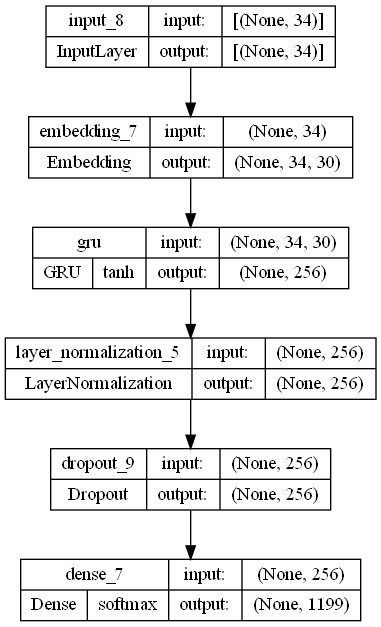

```python
tf.keras.utils.plot_model(gruModel, show_shapes = True, expand_nested = True, show_layer_activations = True)
```

### SUMMARY OF RECURRENT NEURAL NETWORK ANALYSIS

For this RNN analysis, I tested with various RNN models, including SimpleRNN, LSTM, GRU, Bidirectional RNN Models and learnt more about how each of these models work and the value they bring to predicting future words based on a given input text.

**Best Performing Model : Single-Layer GRU Model + 256 Units**

Based on the analysis, it is clear that we have to leverage on both existing metrics such as validation perplexity, validation loss and human evaluation in order to truly be able to analyze the performance of the model. Metrics is important, but human evaluation for the generated sentences is critical as well to ensure that the sentences generated do make sense.